# Mieten in Deutschland

Worin liegen Probleme und Schwierigkeiten im deutschen Mietmarkt

# Motivation

Die Mietpreise in Deutschland spielen eine wichtige Rolle für eine Vielzahl der deutschen Bevölkerung, doch nicht alle Gemeinden sind gleichermaßen von hohen Mieten betroffen. Faktoren wie die Lage einer Stadt, das Angebot an Wohnraum, das Alter der Gebäude oder der Familienstand der Bewohner beeinflussen die Höhe der Mieten. Dies werden Sie in diesem Projekt anhand von Zensus-Daten auf Gemeindeebene für das Jahr 2022 genau untersuchen. Besonders interessant ist dabei, wie sich Mietpreise nicht nur zwischen verschiedenen Städten, sondern auch innerhalb einer Stadt unterscheiden. Sie werden feststellen, dass die Ursachen für diese Mietunterschiede komplex und vielschichtig sind. Ihre Aufgabe ist es, durch fundierte Analysen herauszuarbeiten, welche Faktoren den größten Einfluss auf die Mietentwicklung haben. Auf Basis dieser Erkenntnisse könnten Sie Handlungsempfehlungen geben, die Politik und Stadtplaner nutzen können, um die Mietpreisentwicklung besser zu steuern und Wohnraum gerechter zu gestalten.

# Datengrundlage

In diesem Projekt werden Sie mit mehreren unterschiedlichen Datensätzen arbeiten. Zum Einen werden Sie Zensusdaten aus dem Jahr 2022 zur Demografie genauer betrachten. Zum Anderen werden Sie Daten zur Wohnungszählung in deutschen Gemeinden und Städten untersuchen. Schließlich benötigen Sie die dazugehörigen Kartendaten, um die Informationen später anschaulich visualisieren zu können. Dort werden Sie die Details der Karten einlesen und darüber hinaus Zahlen zu Mieten selbstständig herunterladen und importieren.

## Einlesen

Mittlerweile wohnen knapp 54% der Menschen in Deutschland zur Miete (Stand 2022). Somit ist Deutschland das Mieterland Nummer 1 in Europa. Im Vergleich dazu haben Länder wie Frankreich (36,6%), Italien (25,7%) oder Spanien (24%) einen deutlich geringeren Anteil an Mietern. Für die Politik ist es besonders interessant zu erfahren, wie sich nun die Mieten in den unterschiedlichen Gemeinden in Deutschland verteilen und ob es Regionen gibt, wo es besonders schwer wird eine neue Wohnung zu finden. Um dies zu beleuchten, sollen Sie nun die nachfolgenden Datensätze genauer analysieren.

1. Lesen Sie den Datensatz `Demografie_Zensus.csv` ein und speichern diesen als `demografie`. Der Datensatz `demografie` enthält für jede Gemeinde mehrere Beobachtungen. Dies liegt daran, dass für jede Altersgruppe der Personen eine eigene Beobachtung vorliegt. Allerdings ist der Datensatz im long-Format, d.h. nicht tidy und damit nicht so, wie Sie ihn für die weitere Datenanalyse benötigen. Nun soll der Datensatz so abgeändert werden, dass jede Gemeinde nur noch eine Beobachtung darstellt. Passen Sie den Datensatz so an, dass Sie für jede `Altersgruppe` eine eigene Spalte erstellen und dort jeweils die Anzahl der Menschen, die Sie der Spalte `Anzahl pro Altersgruppe` entnehmen können, eingetragen wird.

Darüberhinaus sollen Sie nun einen weiteren Datensatz `Wohnungen_Zensus.csv` einlesen, welcher Informationen zu den einzelnen Wohnungen in den Gemeinden enthält. Speichern Sie den Datensatz in der Variable `wohnungen` ab. Vereinen Sie ihren Datensatz `demografie` mit dem Datensatz `wohnungen` und speichern Sie diesen als `zensus_daten` ab. Verwenden Sie für ihren “Join” die Variable `Regionalschlüssel`.

Beantworten Sie anschließend die Frage, welche Art von “Join” sich in diesem Fall anbietet und warum?

In diesem Fall bietet sich der Left Join auf Wohnungen mit Demografie an, da die Daten später weiterverarbeitet werden sollen. Durch den Left Join wird vermieden, dass unvollständige Informationen verloren gehen, die später zu Fehlern bei Berechnungen führen könnten. Zudem möchten wir mit beiden Datensätzen Analysen durchführen. Durch den Left Join wird sichergestellt, dass sowohl alle demografischen als auch die Wohnungsdaten enthalten sind.

2. Schränken Sie nun Ihren erstellten Datensatz auf folgende Variablen ein:
- `Name_Gemeinde`
- `Landkreis`
- `0_Insgesamt_`
- `Regionalschlüssel`
- `Alter_infr__` (01 bis 11)
- `FAMSTND_KURZ__` (1 bis 5)
- `Einwanderungserf_ausf__1`
- `Einwanderungserf_ausf__21`
- `Einwanderungserf_ausf__22`
- `Einwanderungserf_ausf__3`
- `Staatsange_kurz__1`
- `Staatsange_kurz__2`
- `BAUJAHR_10JA__` (01 bis 10)
- `WOHNFLAECHE_20S__` (01 bis 10)
- `QMMIETE`
- `LEQ`
- `ETQ`
- `FLAECHE`
- `Wohnungen_gesamt`

Beschreiben Sie weiterhin den Datensatz. Orientieren Sie sich hierbei an folgenden Fragen und nutzen Sie das bereitgestellte README zum Datensatz:

- Was ist eine Beobachtung?
- Wie viele Variablen hat der Datensatz?
- Welche Variablen enthält der Datensatz? Bitte beschreiben Sie diese Variablen kurz!
- Welche Städte mit mehr als 500.000 Einwohnern sind im Datensatz?
- In wie viel Prozent der Fälle haben Sie Informationen zu allen Variablen einer Beobachtung?

```
## [1] 10786    51
```

```
## # A tibble: 15 × 1
##    Landkreis
##    <chr>
##  1 Berlin, Stadt
##  2 Bremen, Stadt
##  3 Dortmund, Stadt
##  4 Dresden, Stadt
##  5 Duisburg, Stadt
##  6 Düsseldorf, Stadt
##  7 Essen, Stadt
##  8 Frankfurt am Main, Stadt
##  9 Hamburg, Freie und Hansestadt
## 10 Region Hannover
## 11 Köln, Stadt
## 12 Leipzig, Stadt
## 13 München, Landeshauptstadt
## 14 Nürnberg
## 15 Stuttgart, Stadtkreis
```

```
## [1] 98.3219
```

1. Eine Beobachtung stellt bei uns eine Zeile mit all den Variablen dar. Dabei handelt es sich um eine Gemeinde mit allen Kennzahlen zu den jeweiligen Variablen.
2. Der Befehl dim gibt uns an, dass der Datensatz im tidy Format 10.786 Beobachtungen(Zeilen) und 51 Variablen(Spalten) enthält.
3. Name_Gemeinde = Der Name der Gemeinde Landkreis = Der Landkreis, dem die Gemeinde zugehört 0_Insgesamt_ = Gesamtbevölkerung in dieser Gemeinde Regionalschlüssel = Zahlencode zur Identifikation der Gemeinde Alter_infr__ (01 bis 11) = Anzahl der Einwohner der Gemeinde innerhalb unterschiedlicher Altersgruppen FAMSTND_KURZ__ (1 bis 5) = Anzahl der Einwohner der Gemeinde mit unterschiedlichen Familienständen Einwanderungserf_ausf__1 = Anzahl der Einwohner der Gemeinde ohne Einwanderungsgeschichte Einwanderungserf_ausf__21 = Anzahl der Einwohner der Gemeinde mit Einwanderungsgeschichte Einwanderungserf_ausf__22 = Anzahl der Einwohner der Gemeinde die Nachkommen von Eingewanderten sind Einwanderungserf_ausf__3 = Anzahl der Einwohner der Gemeinde die eine einseitige Einwanderungsgeschichte haben Staatsange_kurz__1 = Anzahl der Einwohner mit deutscher Staatsangehörigkeit Staatsange_kurz**2 = Anzahl der Einwohner mit Ausländischer Staatsangehörigkeit BAUJAHR_10JA** (01 bis 10) = Anzahl der Wohnungen einer Gemeinde, die einem Zeitraum von unterschiedlichen Baujahren zugehören WOHNFLAECHE_20S__ (01 bis 10) = Anzahl der Wohnungen einer Gemeinde, die unterschiedliche Intervalle von Wohnfläche haben QMMIETE = Durchschnittliche nettokaltmiete pro Quadratmeter einer Gemeinde LEQ = Leerstandsquote in % von Wohnungen einer Gemeinde ETQ = Eigentümerquote in % von Wohnungen einer Gemeinde FLAECHE = Durchschnittliche Fläche der Wohnungen einer Gemeinde Wohnungen_gesamt = Gesamtanzahl der Wohnungen einer Gemeinde
4. Wir haben insgesamt 15 Gemeinden, welche eine Gesamteinwohnerzahl von über 500.000 Einwohner haben. Diese sind: Hamburg, Freie und Hansestadt  
   Region Hannover  
   Bremen, Stadt  
   Düsseldorf, Stadt  
   Duisburg, Stadt  
   Essen, Stadt  
   Köln, Stadt  
   Dortmund, Stadt  
   Frankfurt am Main, Stadt  
   Stuttgart, Stadtkreis München, Landeshauptstadt  
   Nürnberg  
   Berlin, Stadt  
   Dresden, Stadt  
   Leipzig, Stadt
5. 98,3219% aller Beobachtungen (Gemeinden) sind vollständig
3. Erstellen Sie in einem nächsten Schritt weitere Variablen, die Sie in ihrer Analyse benötigen. Diese Variablen sollen folgende Eigenschaften umfassen:
- Je eine Variable für den Anteil kleiner, mittlerer und großer Wohnungen, wobei kleine Wohnungen (<= 59 m²), mittlere Wohnungen (60 - 159 m²) und große Wohnungen (>= 160 m²) als Anteil an den `Wohnungen_gesamt` abgebildet werden sollen.
- Je eine Variable für den Anteil neuer und alter Wohnungen. Neue Wohnungen umfassen alle Wohnungen, die ab 2010 gebaut wurden und alte Wohnungen sind alle Wohnungen vor 1950. Auch hier soll wieder der Anteil an allen Wohnungen (`Wohnungen_gesamt`) berechnet werden.
- Das Verhältnis von Personen mit deutscher Staatsangehörigkeit zu allen Bürgern der Gemeinde einschliesslich Personen mit ausländischer Staatsangehörigkeit und Personen mit dem Status “staatenlos”, “ungeklärt” und “ohne Angabe” über `Staatsange_kurz__1` und `Staatsange_kurz__2`. Hier soll der Anteil deutscher Bürger im Verhältnis zu allen Bürgern der Gemeinde bestimmt werden.

*Hinweis:* Runden Sie die Werte für die neu erstellte Variable sinnvoll!

```
## # A tibble: 6 × 57
## # Groups:   Name_Gemeinde [6]
##   Name_Gemeinde Landkreis             Bevölkerung_Insgesamt `Alter_<_3Jahre`
##   <chr>         <chr>                                 <dbl>            <dbl>
## 1 Aach          Trier-Saarburg                         1096               37
## 2 Aach, Stadt   Konstanz                               2285               62
## 3 Aachen, Stadt Städteregion Aachen                  261178             6507
## 4 Aalen, Stadt  Ostalbkreis                           67139             1964
## 5 Aarbergen     Rheingau-Taunus-Kreis                  6225              159
## 6 Aasbüttel     Steinburg                               149                3
## # ℹ 53 more variables: `Alter_3-5_Jahre` <dbl>, `Alter_6-9_Jahre` <dbl>,
## #   `Alter_10-15_Jahre` <dbl>, `Alter_16-18_Jahre` <dbl>,
## #   `Alter_19-24_Jahre` <dbl>, `Alter_25-39_Jahre` <dbl>,
## #   `Alter_40-59_Jahre` <dbl>, `Alter_60-66_Jahre` <dbl>,
## #   `Alter_67-74_Jahre` <dbl>, `Alter_>=_75_Jahre` <dbl>,
## #   Regionalschlüssel <dbl>, Ledige_Personen <dbl>,
## #   Verheiratete_Personen <dbl>, Verwitwete_Personen <dbl>, …
```

4. Um Karten wie bspw. in der Case Study zu erstellen, benötigen Sie Kartendaten in Form von Shapefiles (Endung .shp). In einer späteren Analyse sollen Sie die einzelnen Städte, bzw. deren Bezirke visualisieren. Hierzu müssen Sie zuerst die nötigen Shape-Files einlesen und Details zu den einzelnen Bezirken herunterladen. Sie sollen Analysen auf Basis von 1km Gitterdaten durchführen. Deshalb sollten Sie sich [diese Geogitter-Daten für die Nettokaltmieten vom statistischen Bundesamt herunterladen](https://www.zensus2022.de/static/Zensus_Veroeffentlichung/Zensus2022_Durchschn_Nettokaltmiete.zip). Speichern Sie die zip-Datei im Ordner `Daten` ab. Weiterhin sollen Sie [die Geogitter-Daten für die Leerstandsquoten herunterladen](https://www.zensus2022.de/static/Zensus_Veroeffentlichung/Marktaktive_Leerstandsquote_in_Gitterzellen.zip). Speichern Sie auch diese im Ordner `Daten` ab und lesen Sie anschließend die .csv-Dateien für Nettokaltmiete und Leerstandsquote (für das 1km-Gitter) ein. Weiterhin benötigen Sie die Karteninformationen für die Visualisierung der Daten. Diese befinden sich in der Datei `Shapefile_Zensus.shp`. Lesen Sie diese mit Hilfe von `st_read()` ein und speichern Sie als `shape_file` ab. Benennen Sie die Variablen in `shape_file` folgendermaßen um:
- gemndnm = Name_Gemeinde
- x_mp_1k = x_mp_1km
- y_mp_1k = y_mp_1km
- gttr1km = gitter1km

Joinen Sie nun noch die beiden Dataframes zu Miete und Leerstandsquote zu `shape_file` hinzu. Verwenden Sie `y_mp_1km` und `x_mp_1km` als Joinvariable.

*Hinweis:* Im ersten Teil der Case-Study wird eine ZIP-Datei in R entpackt. Gehen Sie hier gleich vor!

# Konsistenzcheck

Nun haben Sie alle Daten zusammen, die Sie für die Analyse der Mieten in Deutschland für das Jahr 2022 benötigen. Somit können Sie nun beginnen, die ersten Analysen zu tätigen!

5. Im Datensatz `zensus_daten`, welchen Sie zuvor eingelesen, aufgearbeitet und zusammengefügt haben, befinden sich einige große deutsche Städte. Sie möchten nun gerne die Daten, welche Sie dort aufbereitet haben, verifizieren. Dafür sollten Sie sich eine externe Quelle suchen, auf deren Basis Sie die Gesamtbevölkerung der unten aufgeführten großen Städte in Deutschland mit denen aus dem Datensatz vergleichen. Die Bevölkerungszahlen in ihrem Datensatz stammen aus dem Jahr 2022.

Erstellen Sie eine Tabelle mit allen nachfolgenden Städten aus dem Datensatz und deren Einwohnern. Achten Sie auf eine schöne Darstellung ihrer Tabelle mittels der Pakete `kableExtra` oder `gt`.

Im Detail sollen folgende Städte in der Tabelle genauer betrachtet werden:

- “Berlin, Stadt”, “Hamburg, Freie und Hansestadt”, “München, Landeshauptstadt”, “Köln, Stadt”, “Frankfurt am Main, Stadt”, “Stuttgart, Landeshauptstadt”, “Düsseldorf, Stadt”, “Leipzig, Stadt”, “Augsburg”, “Ingolstadt”, “Ulm, Universitätsstadt”, “Reutlingen, Stadt”

Sind die Anzahl der Einwohner in ihren Daten korrekt? Nutzen Sie eine externe Datenquelle (bitte benennen und in ihrer Antwort verlinken) und führen Sie einen kurzen Konsistenzcheck durch.

| Ausgewählte Städte Gemeinde Namen | Ausgewählte Städte Bevölkerung |
| --- | --- |
| Augsburg | 294.647 |
| Berlin, Stadt | 3.596.999 |
| Düsseldorf, Stadt | 611.258 |
| Frankfurt am Main, Stadt | 743.268 |
| Hamburg, Freie und Hansestadt | 1.808.846 |
| Ingolstadt | 136.468 |
| Köln, Stadt | 1.017.355 |
| Leipzig, Stadt | 598.899 |
| München, Landeshauptstadt | 1.478.638 |
| Reutlingen, Stadt | 116.925 |
| Stuttgart, Landeshauptstadt | 610.458 |
| Ulm, Universitätsstadt | 127.116 |

Die Daten aus [Destatis](https://www-genesis.destatis.de/datenbank/online/url/0ac56688) stammen vom Stichtag 31.12.2022 und weisen nur geringe Abweichungen zu den Zensusdaten auf. Die größte Abweichung finden wir bei der Bevölkerungszahl in Berlin mit einer Differenz von ca. 100.000, und die geringste Abweichung hat Ulm mit einer Differenz von ca. 1.000 Einwohnern.  
Relativ zur Gesamtbevölkerung der Städte sind die Abweichungen eher gering, und wir können davon ausgehen, dass unsere Daten die Realität gut widerspiegeln.  
Zudem war der Stichtag des Zensus 2022 der 30.06.2022, was ein halbes Jahr vor den Daten des Statistischen Bundesamtes (Destatis) liegt, sodass die Abweichungen auf die zeitliche Differenz zurückgeführt werden können.

# Deskriptive Analysen

6. Schauen Sie sich in einem nächsten Schritt an, wie die Variablen im Datensatz `zensus_daten` über alle Gemeinden und Städte hinweg verteilt sind. Konkret sollten Sie eine Tabelle erstellen, welche Informationen zu folgenden Variablen enthält:
- verschiedene Baujahre der Wohnungen
- durchschnittlicher Quadratmeterpreis
- Leerstandsquote
- Eigentümerquote
- durchschnittliche Wohnfläche
- Anteil kleiner, mittlerer und großer Wohnungen
- Einwohner

Berechnen Sie zu jeder Variablen den Mittelwert, den Median, das Minimum, das Maximum, die Standardabweichung, sowie das 25%- und das 75%- Quantil bezogen auf alle Gemeinden. Bei den Variablen Leerstandsquote, Eigentümerquote, durchschnittliche Wohnfläche, durchschnittlicher Quadratmeterpreis und Anteil kleiner, mittlerer und großer Wohnungen soll der Mittelwert als gewichteter Mittelwert nach der absoluten Anzahl an Wohnungen berechnet werden. Heben Sie die Variablen in ihrer Tabelle entsprechend hervor, bei denen sie den gewichteten Mittelwert bestimmt haben.

Beschreiben und interpretieren Sie Ihre Tabelle. Begründen Sie auch, warum es bei den genannten Variablen sinnvoll ist, den nach Anzahl der Wohnungen gewichteten Mittelwert zu verwenden. Würde es ihrer Ansicht nach Sinn machen, statt nach Wohnungen nach Einwohnern zu gewichten? Begründen Sie auch, bei welchen Variablen eine Betrachtung der Mittelwerte, Standardabweichungen und Quantile ihrer Ansicht nach als sinnvoll erscheint. Wo ist dies weniger gut geeignet? Bei welchen Variablen gibt es Auffälligkeiten? Gibt es Ausreißer nach oben oder unten?

Achten Sie auf eine schöne Darstellung ihrer Tabelle mittels der Pakete `kableExtra` oder `gt`!

*Hinweis 1:* Wenn bei den Variablen Wohnungen_klein, Wohnungen_mittel und Wohnungen_groß Werte mit `NaN` oder `Inf` auftauchen, so ersetzen Sie diese durch `NAs`.

*Hinweis 2:* Die Anzahl der Wohnungen nach Alters- bzw. Baujahrsgruppen können den Variablen entnommen werden, welche mit `BAUJAHR_10JA__` beginnen.

| Attribute | Mean | Median | Min | Max | SD | Q25 | Q75 |
| --- | --- | --- | --- | --- | --- | --- | --- |
| Wohnungen_Baujahr_<_1919 | 527.25 | 111.00 | 0.00 | 520700.00 | 5699.83 | 50.00 | 316.00 |
| Wohnungen_Baujahr_1919-1949 | 410.06 | 68.00 | 0.00 | 281150.00 | 3531.03 | 28.00 | 220.00 |
| Wohnungen_Baujahr_1950-1959 | 458.95 | 60.00 | 0.00 | 193475.00 | 3948.50 | 20.00 | 198.00 |
| Wohnungen_Baujahr_1960-1969 | 607.39 | 95.00 | 0.00 | 261728.00 | 4356.11 | 30.00 | 337.00 |
| Wohnungen_Baujahr_1970-1979 | 578.86 | 113.00 | 0.00 | 239857.00 | 3428.06 | 33.00 | 388.75 |
| Wohnungen_Baujahr_1980-1989 | 395.48 | 91.00 | 0.00 | 223683.00 | 2678.94 | 29.00 | 294.75 |
| Wohnungen_Baujahr_1990-1999 | 479.17 | 124.00 | 0.00 | 141456.00 | 2133.67 | 39.00 | 407.00 |
| Wohnungen_Baujahr_2000-2009 | 251.89 | 69.00 | 0.00 | 57008.00 | 1115.38 | 23.00 | 203.00 |
| Wohnungen_Baujahr_2010-2015 | 129.86 | 26.00 | 0.00 | 45389.00 | 829.21 | 8.00 | 88.00 |
| Wohnungen_Baujahr_>=_2016 | 156.03 | 33.00 | 0.00 | 80878.00 | 1102.87 | 9.00 | 115.00 |
| Durchschnitt_Quadratmeterpreis | 7.01 | 5.53 | 0.00 | 13.84 | 1.38 | 4.82 | 6.46 |
| Leerstandsquote | 4.32 | 4.74 | 0.00 | 50.00 | 3.11 | 3.45 | 6.58 |
| Eigentümerquote | 44.39 | 68.75 | 13.49 | 100.00 | 12.69 | 60.22 | 76.08 |
| Durchschnittliche_Wohnfläche | 94.36 | 116.25 | 64.92 | 239.54 | 15.40 | 105.01 | 125.13 |
| Einwohner | 7668.39 | 1797.00 | 9.00 | 3596999.00 | 49519.18 | 655.25 | 5505.00 |
| Anteil_kleine_Wohnungen | 23.12 | 8.86 | 0.00 | 59.05 | 8.00 | 5.72 | 14.23 |
| Anteil_mittlere_Wohnungen | 67.75 | 72.98 | 0.00 | 100.00 | 6.09 | 69.22 | 75.97 |
| Anteil_große_Wohnungen | 9.13 | 16.35 | 0.00 | 100.00 | 7.56 | 11.11 | 21.38 |

In der generierten Tabelle sind die verschiedenen Wohnungsbaujahrgänge, der durchschnittliche Quadratmeterpreis, die Leerstands- und Eigentümerquote, sowie die durchschnittliche Wohnfläche und die Einwohnerzahl enthalten. Die dazugehörigen statistischen Kennzahlen sind der Mittelwert (Mean), Median, Minimal- und Maximalwert (Min/Max), die Standardabweichung sowie das untere und obere Quantil (Q25/Q75).

Beim durchschnittlichen Quadratmeterpreis liegt der Mittelwert bei 7,00 €, wobei der Median niedriger bei 5,53 € liegt. Dies deutet auf eine ungleichmäßige Verteilung der Preise hin, mit einem relativ hohen Maximalwert (13,84 €). Die Standardabweichung (1,38 €) zeigt, dass es moderate Preisunterschiede gibt.  
- Beim gewichteten Mittelwert wäre es sinnvoll, den durchschnittlichen Quadratmeterpreis nach der Anzahl der Wohnungen zu gewichten, da dies einen genaueren Durchschnitt ergeben würde, der stärker von Regionen mit vielen Wohnungen beeinflusst wird. Dadurch könnten Preisspitzen in kleineren Regionen abgeschwächt werden.  
- Eine Gewichtung nach Einwohnerzahl würde allerdings weniger Sinn ergeben, da der Preis eher durch das Angebot an Wohnraum als durch die Anzahl der Einwohner beeinflusst wird.

Bei der Leerstandsquote liegt der Mittelwert bei 4,32 %, wobei der Maximalwert 50 % erreicht. Der Maximalwert von 50 % stellt einen extremen Ausreißer dar und deutet auf eine Region hin, in der die Hälfte der Wohnungen leer steht.  
- Der hohe Maximalwert ist definitiv ein Ausreißer, da die Leerstandsquoten in den meisten Regionen deutlich darunter liegen (Median: 4,74 %).

Die Eigentümerquote zeigt an, wie viel Prozent der Wohnungen von ihren Bewohnern selbst bewohnt werden. Der Mittelwert liegt bei etwa 44,39 %, was auf eine relativ gleichmäßige Verteilung zwischen Miet- und Eigentumswohnungen hinweist. Es gibt jedoch starke Schwankungen, da der Maximalwert bei 100 % liegt.  
- Regionen mit einer Eigentümerquote von 100 % (Maximalwert) könnten ländliche Gebiete oder Regionen mit vielen Einfamilienhäusern sein.

Die durchschnittliche Wohnfläche liegt bei 94,36 m². Dieser Wert ist relativ groß, was auf einen Wohnungsbestand mit vielen geräumigen Wohnungen hinweist. Der Maximalwert von 239,54 m² könnte für besonders große Wohnungen oder Einfamilienhäuser stehen.  
- Allerdings zeigt der hohe Maximalwert an, dass es in bestimmten Regionen sehr große Wohnungen gibt. Diese könnten wiederum das Gesamtbild verzerren, wenn man nicht nach der Anzahl der Wohnungen gewichtet.

Der Mittelwert der Einwohner pro Region liegt bei etwa 7.668. Der Maximalwert von knapp 3,6 Millionen Einwohnern ist eindeutig ein Ausreißer und könnte eine Großstadt wie Berlin oder Hamburg repräsentieren.  
- Der sehr hohe Maximalwert (3,6 Millionen) deutet auf einen großen Unterschied in der Größe der betrachteten Städte und Regionen hin. Dieser Ausreißer könnte das Gesamtbild verzerren, weshalb eine Gewichtung nach Wohnungen hier sinnvoller wäre als eine Gewichtung nach Einwohnern.

Fazit: Es wäre sinnvoll, den nach der Anzahl der Wohnungen gewichteten Mittelwert zu verwenden, insbesondere für den Quadratmeterpreis und die Wohnfläche. Dies würde ein genaueres Bild geben, da Regionen mit vielen Wohnungen stärker in die Berechnung einfließen. Eine Gewichtung nach Einwohnern würde bei vielen Variablen weniger Sinn ergeben, da der Wohnungsmarkt eher durch das Angebot (Anzahl der Wohnungen) als durch die Nachfrage (Einwohner) geprägt ist.

7. Die Verteilung des Alters der Wohnungen scheint bereits ein Faktor zu sein, der sich auf den Mietpreis auswirken kann, da doch deutlich weniger Wohnungen ab den 2000er Jahren gebaut wurden. Nun sollen Sie etwas tiefer in ihren Datensatz eintauchen und weitere Faktoren analysieren, die sich zum einen zwischen Städten und Gemeinden unterscheiden und darüberhinaus herausfinden, ob diese Faktoren einen Einfluss auf den Mietpreis haben:

Erstellen Sie 4 Punktdiagramme in denen Sie

- die durchschnittliche Fläche je Wohnung,
- die Leerstandsquote je Gemeinde,
- Anteil alter Wohnungen je Gemeinde,
- Anteil neuer Wohnungen je Gemeinde,

auf der x-Achse abtragen und auf der y-Achse jeweils die durchschnittliche Nettokaltmiete pro Quadratmeter. Verwenden Sie hier nun alle Gemeinden im Datensatz, um ein Gesamtbild zu erhalten und ordnen Sie die 4 Diagramme so an, dass ein Vergleich zwischen den Schaubildern schnell und einfach möglich ist. Beschreiben und interpretieren Sie die Diagramme. Gehen Sie hierbei insbesondere auf folgende Fragen ein:

- Welche Variablen scheinen besonders stark mit dem Mietpreis korreliert zu sein?
- Was könnte die Zusammenhänge erklären?

*Hinweis:* Achten Sie darauf das bei nebeneinander angeordneten Grafiken die y-Achse gleich sein sollte.

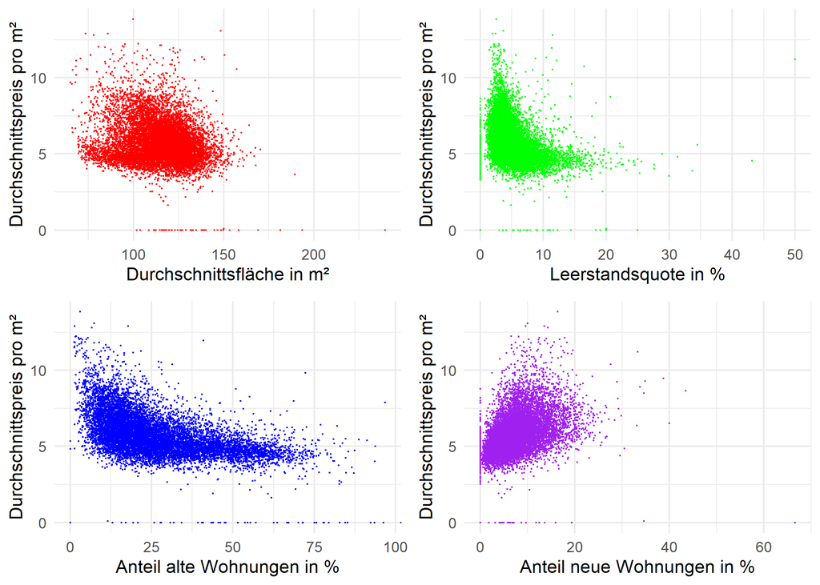

Zuerst muss gesagt werden, dass es bei manchen Gemeinden keine vollständigen Angaben gibt. Diese sind die Punkte in allen Diagrammen, die auf der X-Achse liegen.

Die erste Grafik links oben zeigt den Zusammenhang zwischen der durchschnittlichen Fläche aller Wohnungen in einer Gemeinde in Quadratmetern und dem durchschnittlichen Preis der Kaltmiete pro Quadratmeter in der Gemeinde. Prinzipiell lässt sich keine wirkliche Korrelation zwischen den beiden Variablen erkennen. Sowohl bei einer geringen durchschnittlichen Wohnungsfläche gibt es sehr hohe und niedrige Preise, als auch bei einer hohen durchschnittlichen Wohnungsfläche sind hohe und niedrige Preise zu finden.

Die zweite Grafik rechts oben zeigt den Zusammenhang zwischen der Leerstandsquote in Prozent einer Gemeinde und dem durchschnittlichen Preis der Kaltmiete pro Quadratmeter in der Gemeinde. Hier ist ein Zusammenhang schon eher ersichtlich. Umso höher die Leerstandsquote in einer Gemeinde ist, desto geringer ist der Durchschnittspreis. Erklären lässt sich dies mit dem überschüssigen Angebot an Wohnungen. Da es in diesen Gemeinden mehr Wohnungen als Bewohner gibt, stehen mehr Wohnungen leer. Damit der Vermieter allerdings überhaupt Einnahmen generieren kann, senkt er den Preis der Miete, um die weniger zahlungskräftigen Nachfrager für sich zu gewinnen. Ist die Leerstandsquote jedoch gering, ist die Nachfrage nicht knapp. Die Vermieter können also eine höhere Miete verlangen. Natürlich gibt es auch bei einer geringen Leerstandsquote niedrige Preise, was auf unterschiedlichste Gründe der Vermieter zurückzuführen ist. Diese könnten ethische Hintergründe oder auch wohnungsspezifische Merkmale sein. Prinzipiell ist also eine Korrelation erkennbar, die negativ ist.

Auch die dritte Grafik links unten zeigt einen erkennbaren Zusammenhang zwischen dem Anteil an alten Wohnungen in einer Gemeinde und dem durchschnittlichen Kaltmietpreis pro Quadratmeter in dieser Gemeinde. Hier lässt sich sehr gut erkennen, dass sich das Alter der Wohnungen auf die Miete auswirkt. Je höher der Anteil an älteren Wohnungen ist, desto niedriger ist der Mietpreis. In den alten Wohnungen wohnen überwiegend ältere Menschen, die noch zu vergünstigten Mieten von früher wohnen. Auf der anderen Seite ist in Gemeinden, in denen der Anteil an alten Wohnungen gering ist, der durchschnittliche Mietpreis pro Quadratmeter in der Regel höher. Dies hängt mit den hohen Neumieten und den gestiegenen Baukosten zusammen. Es kann also gesagt werden, dass es hier eine negative Korrelation gibt.

Die vierte Grafik rechts unten zeigt ebenfalls einen erkennbaren Zusammenhang zwischen dem Anteil an neuen Wohnungen in einer Gemeinde und den durchschnittlichen Kaltmietpreisen pro Quadratmeter in dieser Gemeinde. Hier ist deutlich zu sehen, dass eine positive Korrelation zwischen diesen Variablen besteht. Je höher der Anteil an neuen Wohnungen ist, desto höher ist auch der Mietpreis pro Quadratmeter im Durchschnitt. Der Grund dafür wurde bereits in der linken Grafik beschrieben: Neumieten sind prinzipiell höher, und auch die Baukosten sind in den letzten Jahren kontinuierlich gestiegen, was sich im Mietpreis niederschlägt.

Allgemein gibt es in jeder Grafik Ausreißer, und die Aussagen sind nicht immer maßgeblich. Es ist tendenziell nur ein Trend zu erkennen, der oben beschrieben wurde.

Weiterhin wäre es von Interesse in die einzelnen Großstädte Deutschlands genauer hineinzuschauen, um dort auf Besonderheiten im Wohnmarkt einzugehen. Im ersten Schritt sollen Sie Eigenschaften in Bezug auf die Wohnungen genauer untersucht werden, um zu verstehen, welche Faktoren den Mietpreis innerhalb der urbanen Räume beeinflussen könnten. Anschließend wäre es von Interesse, auch die demografischen Merkmale der Mieterinnen und Mieter in den Blick zu nehmen. Dabei stellt sich die Frage, ob und in welchem Maße diese Einfluss auf die Mietpreise und deren Struktur nehmen.

In der vorherigen Aufgabe wurden Zusammenhänge zwischen dem Alter von Wohnungen und dem Mietpreis auf Gemeindeebene untersucht. Nun soll der Fokus darauf liegen, wie sich die Wohnungen in größeren Städten hinsichtlich ihres Alters verteilen.

8. Erstellen Sie ein Balkendiagramm für alle nachfolgenden Städte: `Stuttgart, Landeshauptstadt`, `Ulm, Universitätsstadt`, `Düsseldorf, Stadt`, `Berlin, Stadt`. Betrachten Sie dabei, wie das Alter der Wohnungen zwischen den Städten variiert. Sie sollen analysieren, wie groß der Anteil der Wohnungen abhängig nach den jeweiligen Baujahrsgruppen in den Städten ist. Tragen Sie in ihrem Balkendiagramm den *Anteil der Wohnungen nach den Baujahren* (auf der y-Achse) gegeben der *Baujahre für jede Stadt* (auf der x-Achse) ab.

Beschreiben und interpretieren Sie die Grafik. Haben Sie diese Unterschiede erwartet? Begründen Sie warum oder warum nicht.

*Hinweis:* Denken Sie daran das Faktorvariablen in ggplot hilfreich sein können.

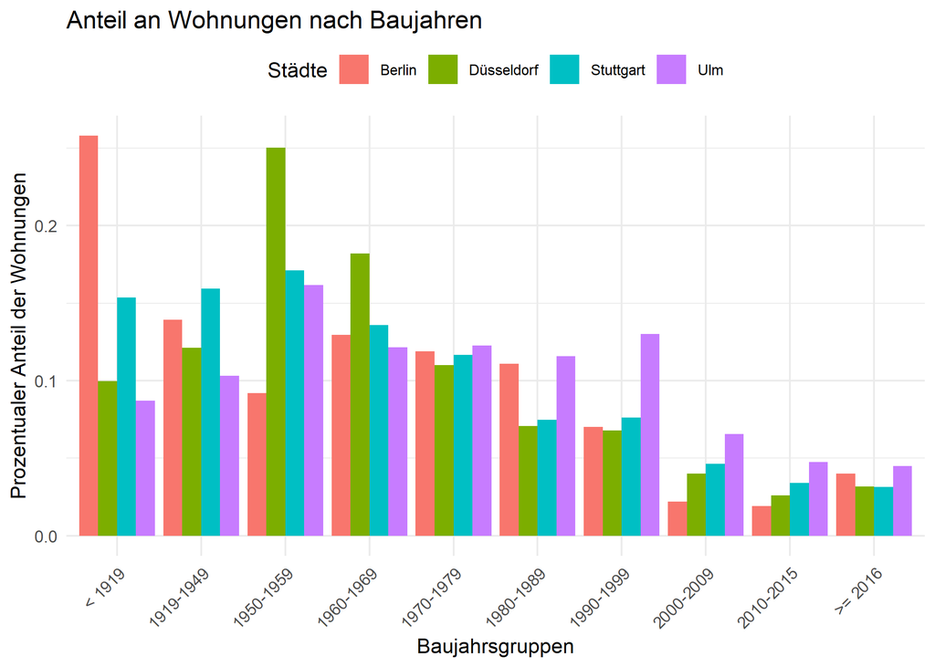

Besonders auffällig ist der Ausschlag von Berlin in der Baujahrsgruppe < 1919 und von Düsseldorf in der Baujahrsgruppe 1950-1959. In der Kategorie < 1919 machen Berliner Wohnungen mehr als 25 % des gesamten Wohnungsbestands aus. Dies lässt sich wahrscheinlich auf die lange Geschichte und die historische Bedeutung der Stadt zurückführen. Interessant ist, dass so viele Gebäude in Berlin trotz der massiven Zerstörungen im Zweiten Weltkrieg erhalten geblieben sind. Im Vergleich dazu hat Ulm mit einem Anteil von knapp 10 % den geringsten Anteil aller hier dargestellten Städte. Dies ist jedoch wenig verwunderlich, da in Ulm rund 80 % der Gebäude in der Innenstadt zerstört wurden.

In der Baujahrsgruppe 1950-1959 fällt Düsseldorf mit einem Anteil von 25 % aller Wohnungen auf. Dies ist vermutlich eng mit der neuen Rolle Düsseldorfs im Zuge des Wiederaufbaus verbunden. Durch das neu gegründete Bundesland Nordrhein-Westfalen und die Ernennung zur Landeshauptstadt kam es zu einem starken Anstieg der Bautätigkeit, da erst die passende Infrastruktur für eine Landeshauptstadt geschaffen werden musste. Zudem spielte auch das “Wirtschaftswunder” eine Rolle, das neue Arbeitsplätze sowie Wohnungen schuf.

9. Wie in der vorherigen Aufgabe zu sehen war, unterscheidet sich die Situation in Städten in Bezug auf die jeweiligen Baujahre der Wohnungen deutlich. Es wäre noch spannend zu sehen, ob auch das Alter der Bewohner, die Familienstände, oder die Einwanderungshistorie der Bewohner mit unterschiedlichen Mietpreisen assoziiert sind. Hier sollen Sie in einem ersten generellen Schritt ein paar demografische Faktoren einbeziehen, inwiefern diese eine Auswirkung haben. Betrachten Sie folgende Eigenschaften genauer:
- Familienstand
- Alter der Bewohner
- Einwanderungsgeschichte

Erstellen Sie eine oder mehrere passende Diagramme oder Grafiken für die in Aufgabe 8 aufgeführten Städte.

Beschreiben und interpretieren Sie diese. Haben Sie diese Unterschiede erwartet? Begründen Sie warum oder warum nicht. Wo gibt es Ihrer Ansicht nach besondere Auffälligkeiten? Warum kann es bei der unterschiedlichen Einteilung der Altersgruppen zu Problemen kommen? Was wären Möglichkeiten, um etwaige Probleme zu vermeiden?

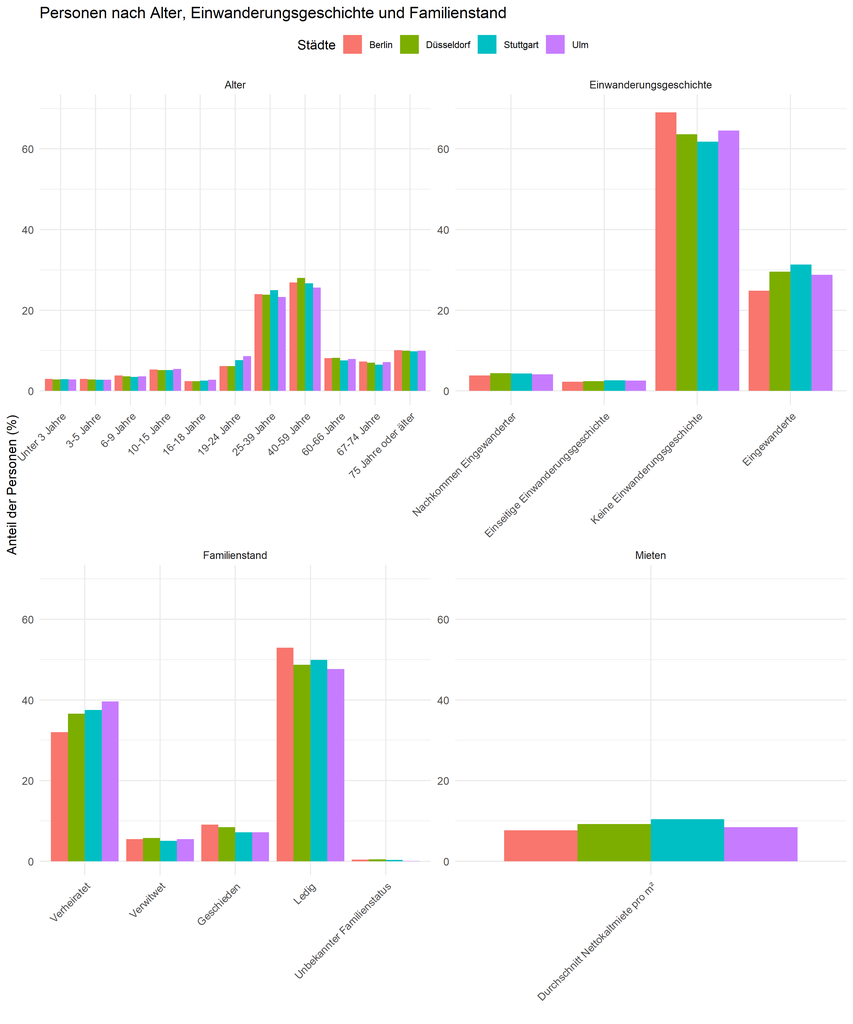

Bei der Grafik zum Alter sehen wir, dass der Großteil der Personen im Bereich der 25-39-Jährigen und im Bereich der 40-59-Jährigen liegt. Einen Zusammenhang zwischen dem prozentualen Anteil des Alters und den Mietpreisen lässt sich jedoch nicht erkennen. Ein großes Problem in der Darstellung ist die Reichweite der Jahrgänge. Natürlich gibt es prozentual gesehen mehr Personen im Alter zwischen 25 und 39 Jahren als Personen unter 3 Jahren. Der eine Bereich umfasst eine Spannweite von 14 Jahren, während der andere nur 3 Jahre umfasst. Ein Vergleich ist also in diesen Abständen allgemein sehr schwer. Die Unterschiede habe ich jedoch erwartet. Auffälligkeiten gibt es keine. Eine Lösung, um möglicherweise auf Zusammenhänge schließen zu können, wäre eine gleichmäßige Aufteilung der Altersgruppen. Zusätzlich ist das Alter unter 18 Jahren bei Mietpreisen nicht von Belang.

Bei der Grafik zur Vorgeschichte ist der größte prozentuale Anteil der Personen ohne Einwanderungsgeschichte. Danach folgt der Anteil der Eingewanderten. Die Anteile der Nachkommen von Eingewanderten und Personen mit einseitiger Einwanderungsgeschichte sind dagegen sehr gering. Besonders zu erwähnen ist der Anteil der Nachkommen von Eingewanderten, da dieser deutlich kleiner ist, als ursprünglich erwartet. Hier ist auch ein Zusammenhang zu den Mietpreisen erkennbar. Die Struktur der Mietpreise entspricht der Struktur der Eingewanderten. Wenn sich verhältnismäßig weniger Eingewanderte in einer Stadt befinden, wirkt sich dies auch auf niedrigere Mietpreise aus. Auf der anderen Seite ist dies bei einer höheren Zahl von Eingewanderten genau umgekehrt.

Bei der Grafik zum Familienstand gibt es erneut keine Auffälligkeiten. Der Großteil ist ledig, danach folgen die Verheirateten. Die Verwitweten und Geschiedenen machen nur einen geringen Teil aus. Interessant ist der Bereich „unbekannt“. Dieser ist zwar nahezu nicht existent, aber dennoch vorhanden. Bei dieser Grafik ist keine Ähnlichkeit zu den Mietpreisen und somit kein signifikanter Zusammenhang erkennbar.

Abschließend kann gesagt werden, dass nur ein erkennbarer Zusammenhang zwischen Mietpreisen und Einwanderungsgeschichte festgestellt werden kann.

In den bisherigen Analysen wurden demografische und wohnungsbezogene Faktoren in verschiedenen Städten Deutschlands untersucht. Dabei lag der Fokus darauf, wie diese Merkmale in unterschiedlichen Regionen das Mietpreisniveau und dessen Struktur beeinflussen. Aufbauend auf diesen Erkenntnissen soll der Blick nun gezielt auf den Vergleich zwischen Ost- und Westdeutschland gelenkt werden. Diese regionale Differenzierung ermöglicht es, potenzielle Unterschiede und Gemeinsamkeiten zwischen den beiden Landesteilen genauer zu analysieren. Insbesondere wird betrachtet, wie sich die Mietpreisstruktur in Ost- und Westdeutschland darstellt und ob sich hierbei spezifische Muster oder Abweichungen erkennen lassen.

10. Betrachten Sie nun die Städte `Dresden, Stadt`, `Chemnitz, Stadt`, `Stuttgart, Landeshauptstadt`, `Ulm, Universitätsstadt`,`Düsseldorf, Stadt`und `Berlin, Stadt`. Vergleichen Sie in einem ersten Schritt die Anzahl an Einwohnern, den Anteil an Menschen, die deutscher Herkunft sind, den Anteil an neuen und alten Wohnungen, sowie die durchschnittlichen Mietpreise. Erweitern Sie ihre Analyse um die durschnittlichen Wohnflächen.

Erstellen Sie für die genannten Städte eine deskriptive Tabelle. Beschreiben und interpretieren Sie diese. Beantworten Sie insbesondere folgende Fragen:

- In wie weit könnte das Alter der Wohnungen eine Rolle für den Mietpreis spielen?
- Gibt es Auffälligkeiten zwischen den einzelnen Städten in Bezug auf Herkunft der Bewohner, Einwohner und Größe der Wohnungen?
- Warum könnte es problematisch sein, wenn Sie die Städte als ein Ganzes betrachten?
- Sind Ihre Ergebnisse auf die ganze Stadt verallgemeinerbar?
- Was sind ihrer Meinung nach Faktoren, die die unterschiedlichen Mietpreise in Ost und West erklären?
- Welche Maßnahmen wären geeignet, um in Düsseldorf, Ulm und Stuttgart die Mietpreisstruktur anzupassen und bezahlbaren Wohnraum zu schaffen?

| Vergleich Ausgewählter Städte Gemeinde Namen | Vergleich Ausgewählter Städte Bevölkerung | Vergleich Ausgewählter Städte Anteil Deutsche Bürger in % | Vergleich Ausgewählter Städte Anteil neue Wohnungen in % | Vergleich Ausgewählter Städte Anteil alte Wohnungen in % | Vergleich Ausgewählter Städte Durchschnitt Miete pro m² | Vergleich Ausgewählter Städte Durchschnitt Wohnfläche in m² |
| --- | --- | --- | --- | --- | --- | --- |
| Berlin, Stadt | 3.596.999 | 80.46 | 5.92 | 39.72 | 7.67 | 73.22 |
| Chemnitz, Stadt | 240.078 | 90.23 | 3.18 | 41.03 | 5.26 | 71.33 |
| Dresden, Stadt | 557.782 | 90.69 | 6.62 | 39.61 | 6.92 | 71.24 |
| Düsseldorf, Stadt | 611.258 | 77.24 | 5.78 | 22.11 | 9.24 | 77.56 |
| Stuttgart, Landeshauptstadt | 610.458 | 74.30 | 6.57 | 31.33 | 10.39 | 79.76 |
| Ulm, Universitätsstadt | 127.116 | 78.22 | 9.26 | 19.02 | 8.48 | 87.64 |

Wir haben nun eine Tabelle, die für die oben genannten Städte die einzelnen Kennzahlen anzeigt.

Wie bereits in einer anderen Aufgabe beschrieben, könnte das Alter der Wohnungen eine beachtliche Rolle bei den Mietpreisen spielen. Ältere Wohnungen neigen dazu, einen veralteten Lebensstandard zu haben, zum Beispiel sind die Fenster schlechter gedämmt, das Heizsystem ist ineffizient und so weiter. Daher ist der Mietpreis in der Regel geringer, um diese Makel zu kompensieren.

Auffällig ist, dass der prozentuale Anteil an alten Wohnungen stark mit den Mietpreisen korreliert. So hat beispielsweise Chemnitz den größten Anteil an alten Wohnungen mit 41,03 % und eine dazugehörige Durchschnittsmiete von 5,26 €. Was jedoch besonders hervorzuheben ist, sind die Städte Stuttgart, Düsseldorf und Ulm. Stuttgart hat im Vergleich einen mittelmäßigen Anteil an alten Wohnungen, allerdings eine enorm hohe Durchschnittsmiete im Vergleich zu den anderen Gemeinden. Diese Auffälligkeit wird noch unterstrichen, da man in diesem Fall davon ausgehen würde, dass es eine hohe Zahl neuer Wohnungen gibt, was jedoch nicht zutrifft. Hier ist die Durchschnittsmiete trotzdem am höchsten. Auch Düsseldorf ist bemerkenswert. Prozentual gesehen gibt es in Düsseldorf mehr ältere Wohnungen als in Ulm, dennoch ist der Mietpreis höher als in Ulm. Zusätzlich fällt auf, dass es in Düsseldorf prozentual auch weniger neue Wohnungen gibt als in Ulm. Wir können also unsere zunächst angesprochene Annahme nicht bestätigen. Auffällig ist jedoch, dass die Mieten in den ostdeutschen Gemeinden geringer sind als in den westdeutschen Gemeinden.

Ein weiteres interessantes Detail zeigt sich beim Mietpreis im Verhältnis zum Anteil der Menschen mit deutscher Staatsangehörigkeit. In den Gemeinden unserer Stichprobe haben die Städte mit den geringsten Mietkosten den höchsten Anteil an deutschen Staatsangehörigen. Ein Grund dafür könnte die Bestandsmiete sein. Wenn es mehr deutsche Staatsangehörige gibt, ist die Wahrscheinlichkeit höher, dass diese schon länger in der Wohnung wohnen und daher eine geringere Miete zahlen. Den Anteil an deutschen Staatsbürgern und die durchschnittliche Wohnfläche könnte man geografisch in Ost- und Westdeutschland aufteilen, was möglicherweise auf die Zeit der BRD und DDR zurückzuführen ist.

Wenn wir Städte als Ganzes betrachten, könnte dies problematisch sein, da es unterschiedlich große Stadtteile gibt, unter denen es auch Slums gibt. Es gibt Teile der Stadt mit besserer und schlechterer Infrastruktur. Die bessere Infrastruktur befindet sich üblicherweise im Stadtzentrum, während die Slums oft an den Stadträndern liegen. Bei einer Stadt-Expansion befinden sich Slums oft näher am Zentrum. Daher ist der prozentuale Anteil an Slums in den verschiedenen Städten unterschiedlich, was zu einer Verzerrung der tatsächlichen Gegebenheiten führen kann. In Berlin gibt es beispielsweise wesentlich mehr heruntergekommene Stadtteile als in Düsseldorf, was den hohen Unterschied bei den Mietpreisen erklären könnte. In den normalen Wohngegenden in Chemnitz könnten die Mietpreise zum Beispiel deutlich höher sein als der hier angegebene Durchschnitt. Es gibt zudem grundlegende Unterschiede zwischen ost- und westdeutschen Gemeinden, wie im vorherigen Absatz bereits erläutert. Daher kann man die Variablen nicht einfach auf eine ganze Stadt verallgemeinern.

Um diese Unterschiede zu regulieren, könnte ein staatlicher Eingriff in Form von Mietpreisbremsen, Renovierungsbeihilfen und Sozialbauten eine mögliche Lösung darstellen.

11. Lesen Sie den [folgenden Artikel](https://www.tagesschau.de/wirtschaft/sozialwohnungen-bau-mangel-101.html). Dort werden Sozialwohnungen thematisiert, warum so viele fehlen und wer davon vor allem betroffen ist. Beantworten Sie anschließend folgende Fragen:
- Welche Bevölkerungsgruppen sind am stärksten von der Sozialwohnungsnot betroffen und inwiefern?
- Was sind Gründe, warum es zu wenige Sozialwohnungen gibt?
- Wie sieht die historische Entwicklung des Sozialwohnungsbaus aus, im Hinblick auf Vorhandensein von Wohnungen und Investitionen in den Bau von neuen Wohnungen?
- Welche Anreize könnten Investoren motivieren, mehr Sozialwohnungen zu bauen?
- Welche innovativen Ansätze können Bauherren verfolgen, um die Kosten für den Wohnungsbau zu senken?

Es gibt zu wenig Sozialwohnungen, da insbesondere viele Familien, die noch vor ein paar Jahren gut abgesichert waren, nun in finanzielle Schieflage geraten sind. Besonders betroffen sind in diesem Fall ärmere Familien. Heute muss man sich auf Wartelisten setzen lassen, um auf eine Sozialwohnung warten zu können.

Die Gründe für diesen Mangel sind vielfältig: steigende Baukosten, hohe Zinsen und die Auswirkungen der Ukraine-Krise, die den Neubau von Sozialwohnungen erheblich beeinträchtigen. Zudem übersteigt die Zahl der aus der Mietbindung gefallenen Wohnungen mittlerweile die Zahl der neu geförderten Bauprojekte.

Für das vergangene Jahr war geplant, 100.000 neue Sozialwohnungen zu schaffen. Doch es gab 27.000 Sozialwohnungen weniger als im Jahr zuvor. Wie bereits erwähnt, liegt dies daran, dass die Zahl der Wohnungen, die aus der Mietbindung gefallen sind, höher ist als die Zahl der neu geförderten Neubauten. Die Gründe für die wenigen Neubauten sind vor allem die stark gestiegenen Zinsen, die hohen Baukosten und die Lieferkettenprobleme durch die Ukraine-Krise. Zudem sprangen viele Investoren bei geförderten Projekten ab, da die Rendite durch die hohen Kosten aufgefressen wurde. Während laufende Projekte noch abgeschlossen werden, sind kaum neue Projekte in Planung.

Anreize für Investoren könnten durch weniger Auflagen, schnellere Genehmigungen und verstärkte Förderungen geschaffen werden. Auch steuerliche Anreize für Unternehmen könnten dazu beitragen, das Problem einzugrenzen. Dies würde das Bauen schneller, einfacher und auch kostengünstiger machen und es ermöglichen, mehr Bauland zu erschließen.

Bauherren sollten zudem intelligenter und günstiger bauen. Beispiele hierfür wären kleinere Treppenhäuser, reduzierte Wandstärken, Holzbauweise, Flachdächer und besserer Schallschutz. Es bedarf zudem mehr Innovationen aus der Industrie.

12. Gerade die Politik ist gefordert, bezahlbaren Wohnraum zu realisieren. Dabei gibt es eine Viezahl an politischen Maßnahmen, die aufgestellt wurden und umfangreich diskutiert werden. Betrachten Sie die folgenden Maßnahmen, welche helfen sollen, die angespannte Lage auf dem Mietmarkt zu entlasten. Argumentieren Sie, warum diese Maßnahmen sinnvoll/nicht sinnvoll sind und in welcher Art und Weise diese umgesetzt werden können.
1. “Fachleute fordern, die Regulierung von Bestandsmieten zu lockern, damit sich ihr Niveau den Neuvertragsmieten annähert, mehr Menschen umziehen und sich Wohnraum besser verteilt.”
2. “Eine weitere Möglichkeit wäre, Mieterhöhungen bei Neuvertragsmieten zu begrenzen.”
3. “Am einfachsten ist es, wenn vor allem in Großstädten, wo bezahlbarer Wohnraum fehlt, mehr gebaut wird.”
4. “Am besten wäre es, wenn zukünftig mehr Vermieter in regelmäßigen Abständen die Miete anpassen.”
1. Dies könnte zu einer besseren Verteilung führen, allerdings könnte es auch viele Vermieter dazu ermutigen, höhere Mieten zu verlangen. Sollten Mieter bereits seit einiger Zeit in einer Wohnung wohnen, ermöglicht diese Veränderung dem Vermieter, die Miete leichter anzupassen, was in einer Mieterhöhung enden könnte. Zudem wird der Schutz der Mieter vor indirektem Rauswurf auf diese Weise umgangen. Diese Veränderung würde den Wohnungsmarkt eher verschlechtern als verbessern.
2. Auch hier würde dies nicht zu einer besseren Mietsituation führen. Wenn die Miete im Laufe der Zeit nicht ausreichend erhöht werden kann, wird die Einstiegsmiete bereits höher angesetzt, was im Hinblick auf den angespannten Wohnungsmarkt kontraproduktiv ist.
3. Diese Lösung scheint sinnvoll. Ein höheres Angebot würde den Preis natürlich senken. Sollte es möglich sein, genug neue Wohnungen zu schaffen, könnte sich der Mietpreis von selbst regulieren, was die Situation deutlich entschärfen würde. Wenn ausreichend Wohnungen vorhanden sind, hat jeder Vermieter das Interesse, seine Wohnung zu vermieten. Ist die Wohnung zu teuer, wird der Mieter sich für eine günstigere Wohnung entscheiden. Der Vermieter muss daher die Miete so anpassen, dass der Mieter keinen Grund hat, sich eine billigere Wohnung zu suchen. Auf diese Weise würde sich der Mietpreis automatisch regulieren.
4. Bei dieser Lösung ist eine Verbesserung der Mietsituation jedoch nicht garantiert. Nur weil der Vermieter die Miete regelmäßiger anpassen soll, bedeutet das nicht, dass er sie auch senkt. Es wäre für den Mieter von Vorteil, wenn der Vermieter die Miete gleich lässt oder sogar senkt. Dies wird jedoch in der Regel nicht geschehen, da der Vermieter seinen Ertrag maximieren möchte.

Fazit: Nur die dritte Situation würde zu einer Verbesserung führen. Dafür müssen jedoch ausreichend Wohnungen geschaffen werden, was sowohl eine Frage des Platzes als auch des finanziellen Aufwands ist. Ein Überschuss an Wohnungen wäre hingegen kontraproduktiv. Es gilt, die exakt notwendige Menge an Wohnungen zu schaffen.

# Einzelne Stadtteile in Deutschland

In allen vorherigen Aufgaben haben Sie die Städte, Gemeinden oder auch Landkreise immer als ein Ganzes betrachtet. Jedoch ist es schwierig gerade in Großstädten wie Berlin, Düsseldorf oder auch Stuttgart allgemeine Aussagen über die Mietsituation auf Stadtebene zu treffen. Dies liegt unter anderem daran, dass unterschiedliche Stadtviertel unterschiedliche demografische Eigenschaften, sowie eine unterschiedliche Mietstruktur aufweisen können. Hier wäre es sinnvoll sich mit dem Stadtbild und der Verteilung der Mieten genauer auseinanderzusetzen, um zu sehen, wie sich Mieten innerhalb der Stadt verteilen. Wie in Aufgabe 10 zu sehen war, weisen die Städte im Westen Deutschlands untereinander, sowie die Städte im Osten ähnliche Merkmale auf, weshalb Sie sich in den folgenden Aufgaben auf je eine große und eine kleinere Stadt aus beiden Regionen konzentrieren.

13. In dieser Aufgabe sollen Sie ihren Datensatz aus Aufgabe 4, bei dem Sie Kartendaten und Informationen zu Mieten und LEQ auf 1km-Gitterebene heruntergeladen und zusammengefügt haben, verwenden und vier Karten zeichnen, welche die Verteilung der Nettokaltmieten in den Stadtteilen der Städte “Stuttgart, Landeshauptstadt”, “Ulm, Universitätsstadt”, “Chemnitz, Stadt” und “Dresden, Stadt” anschaulich visualisieren.

Erstellen Sie vier Grafiken, beschreiben und interpretieren diese. Gehen Sie insbesondere auf folgende Fragen ein:

- Welche Besonderheiten fallen Ihnen bei diesen Städten auf?
- Gibt es eine Segregation in Bezug auf die Mieten in einzelnen Stadtteilen?
- Falls es eine Segregation gibt, welche Konsequenzen könnte dies haben?
- Welche Rolle spielen geografische oder infrastrukturelle Faktoren bei den Mietpreisen?
- Gibt es Unterschiede zwischen Städten im Osten und Westen Deutschlands, falls ja, welche Einflüsse in Bezug auf Wirtschaft und Arbeitsmarkt könnte dies in den jeweiligen Städten haben?

*Hinweis:* Wenn Sie einheitliche Legenden für die Karten haben möchten und die vier Städte nebeneinander oder untereinander darstellen wollen, so empfiehlt sich das Paket `ggpubr` und dort der Befehl `ggarrange`.

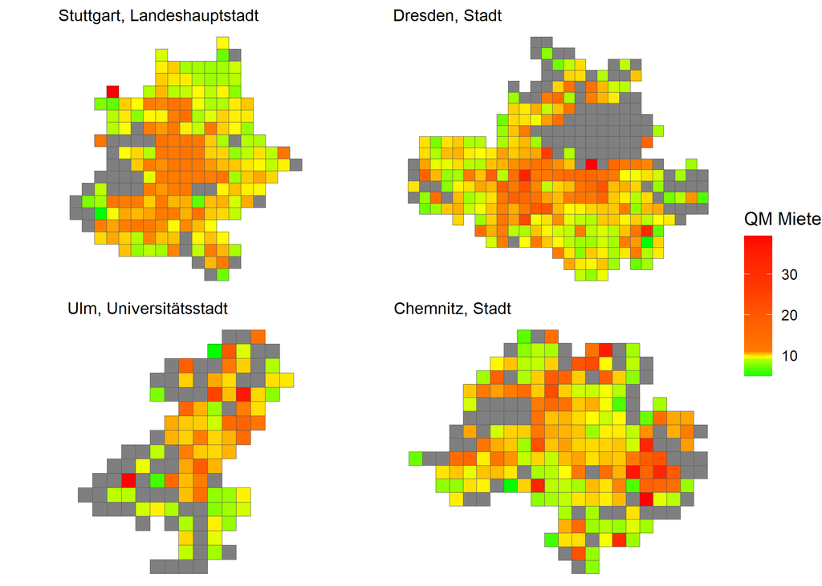

Stuttgart Zunächst fällt auf, dass die höheren Mietpreise im Stadtzentrum liegen, mit einer Tendenz zur Südseite hin. Im Westen der Stadt gibt es einige Bereiche, in denen die Mietpreise nicht bekannt sind, was die Einschätzung erschwert. Besonders am südöstlichen Rand der Stadt sind günstigere Mietpreise pro Quadratmeter zu finden.

Chemnitz Hier zeigt sich ein anderes Bild. Die Mieten sind zwar im Stadtzentrum etwas höher, doch im Gegensatz zu den anderen Städten scheinen sich die höheren Mietpreise eher um das Zentrum herum zu konzentrieren. Wie in den anderen Städten sind die Mietpreise am Stadtrand niedriger. Da der Bahnhof relativ weit ins Stadtzentrum hineinragt, könnte Zuglärm ein Grund für die niedrigeren Mieten nordöstlich des Stadtzentrums sein.

Dresden Auffällig ist, dass im Norden der Stadt viele Mietpreise nicht bekannt sind. Dies könnte auf die Lage an der Elbe und die dort vorhandenen Parkanlagen zurückzuführen sein. Auch in Dresden ist eine starke Konzentration der Mietpreise im Stadtzentrum, insbesondere in der Altstadt, zu beobachten. Zu den Rändern hin sinkt der Mietpreis wieder.

Aufgrund der wirtschaftlichen Stärke Stuttgarts und der vielen großen Unternehmen, die für einen starken Zuzug sorgen, sind die Mieten in Stuttgart im Vergleich zu Chemnitz deutlich höher. Dies liegt zum einen daran, dass es in Stuttgart kaum Leerstand gibt, und zum anderen steigen die Mieten durch die höheren Löhne, da die Bewohner bereit sind, mehr für Wohnraum zu zahlen.  
Auch die Infrastruktur, insbesondere der öffentliche Nahverkehr, spielt eine wichtige Rolle bei den Mietpreisen. Bis auf Chemnitz weisen die Stadtzentren eine höhere Durchschnittsmiete auf. Dies lässt sich vermutlich darauf zurückführen, dass sich Arbeitsplätze sowie Einkaufsmöglichkeiten hauptsächlich in den Innenstädten befinden. Eine Wohnung in zentraler Lage ist daher für viele Menschen attraktiv, und sie sind nicht bereit, die gleiche Miete für eine Wohnung am Stadtrand zu zahlen.

[figure not shown]

14. Nachdem Sie in Aufgabe 13 die Verteilung der Mieten der einzelnen Stadtteile visualisiert haben, sollten Sie in dieser Aufgabe den Anteil der Leerstandsquoten in den Stadtteilen der Städte “Stuttgart, Landeshauptstadt”, “Ulm, Universitätsstadt”, “Chemnitz, Stadt” und “Dresden, Stadt” veranschaulichen.

Erstellen Sie vier Grafiken, beschreiben und interpretieren diese. Gehen Sie insbesondere auf folgende Fragen ein:

- Was könnten Gründe sein, dass die Leerstandsquote in bestimmten Stadtteilen höher ist, als in anderen?
- Welche Besonderheiten fallen Ihnen bei diesen Städten auf? Auch im Hinblick auf ihre Erkenntnisse aus Aufgabe 13.
- Vergleichen Sie die Grafiken aus Aufgabe 13 und Aufgabe 14. Was könnte der Grund für die unterschiedlichen Muster sein?
- Welche Maßnahmen ergreifen Städte mit hohen Leerstandsquoten, um diese zu reduzieren?

*Hinweis:* Wenn Sie einheitliche Legenden für die Karten haben möchten und die vier Städte nebeneinander oder untereinander darstellen möchten, so empfiehlt sich das Paket `ggpubr` und dort der Befehl `ggarrange`.

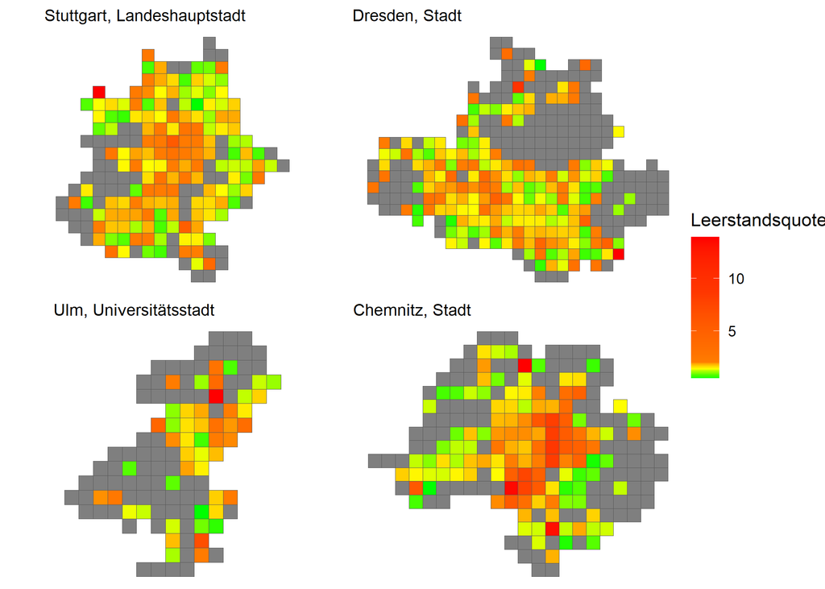

Unerwartet zeigt die Grafik, dass sich ein Großteil des Leerstands in Stuttgart, Ulm und Chemnitz im Stadtzentrum befindet. Dies könnte darauf hindeuten, dass viele Menschen bereit sind, einen längeren Arbeitsweg in Kauf zu nehmen, wenn sie dadurch geringere Mietkosten haben.

In Dresden hingegen scheint es kein klares Muster zu geben, da der Leerstand relativ gleichmäßig verteilt ist. Dies könnte jedoch auch auf die vielen fehlenden Daten zu den Mieten zurückzuführen sein. Eine präzise Aussage über Ulm ist ebenfalls schwierig. Basierend auf den vorhandenen Daten könnte man jedoch vermuten, dass auch hier in der Innenstadt ein höherer Leerstand vorliegt.

15. Die aktuellen Mietpreise und deren Entwicklungen hindern in Deutschland immer mehr Menschen daran, dass sie sich eine neue geeignete Wohnung suchen. Personen, die aufgrund ihrer aktuellen Lebenssituation sich nach einer neuen Wohnung umsehen, finden oft keine oder können sich diese nicht leisten. Doch worin liegen die Ursachen und Probleme?

Beantworten Sie hierzu folgende Fragen:

- Was versteht man unter dem Lock-in-Effekt, speziell in Bezug auf den Mietmarkt? Wer ist davon vor allem betroffen und warum?
- Gibt es aktuell Möglichkeiten, die vor allem diese “betroffenen” Personen haben, um an bezahlbaren Wohnraum zu gelangen?
- Worin liegen die Ursachen, dass Bestandsmieten (Mieten aus bestehenden Verträgen) und Angebotsmieten (Mieten aus Neuverträgen) so stark voneinander abweichen?

Gehen Sie in ihrer Argumentation auch auf die Grafiken und Ergebnisse der Aufgaben 11, 13 und 14 ein.

Der Lock-in-Effekt beschreibt eine enge Bindung zwischen Kunden und Anbietern. Hierbei ist es für den Kunden aufgrund verschiedener Einflüsse, wie zum Beispiel hoher Wechselkosten oder anderer Wechselbarrieren, erschwert, den Anbieter zu wechseln. Speziell im Wohnungsmarkt bedeutet der Lock-in-Effekt, dass sich Menschen das Umziehen nicht leisten können oder keine Möglichkeit finden. In Aufgabe 11 wurde bereits auf sozial schwächere Menschen hingewiesen. Diese finden aufgrund des Wohnungsmangels keine passende Wohnung oder können sich diese nicht leisten. Besonders ältere Menschen, deren Kinder bereits ausgezogen sind, wohnen in größeren Wohnungen mit vergleichsweise niedriger Miete. Ein Umzug würde für diese Personen vermutlich eine kleinere Wohnung zu höheren Mietkosten bedeuten. Möchte eine Familie in eine größere Wohnung ziehen, so ist dies meistens nur zu einem erheblich höheren Preis möglich. Die Mieter sind also in ihrer Wohnung „eingesperrt“.

Da ältere Menschen oft zu viel Platz und junge Familien zu wenig Platz haben, wäre es eine mögliche Lösung, wenn diese Menschen ihre Wohnungen tauschen könnten. Genau dies stellt eine Möglichkeit dar, um den Bedürfnissen der Betroffenen entgegenzukommen. Heutzutage ist es unter Umständen möglich, Wohnungen zu tauschen, was allerdings schnell auf gewisse Hürden stößt. Dieses Konzept ist sowohl bei Mietern als auch bei Vermietern noch nicht besonders bekannt.

Der kostenmäßige Unterschied zwischen Bestandsmieten und Angebotsmieten lässt sich relativ leicht erklären. In Deutschland gibt es gesetzliche Regelungen, die die Höhe der Mieten für bestehende Mietverträge begrenzen. Da die Mietpreise früher deutlich niedriger waren, ist es aufgrund des frühen Vertragsschlusses nicht möglich, den bestehenden Mietpreis so stark zu erhöhen, dass er dem heutigen Niveau entspricht. Wie bereits in Aufgabe 11 erwähnt, liegt die Anzahl der Neubauten unter dem erwarteten Niveau, was das Nachfrage- und Angebotsverhältnis ausnutzt und zu höheren Mietpreisen führt. Wird eine ältere Wohnung schließlich neu vermietet, fallen hohe Renovierungskosten an, die durch den Preis der neuen Angebotsmiete gedeckt werden müssen. In den Grafiken der 13. Aufgabe wird deutlich, dass die Mieten in den inneren Stadtteilen tendenziell höher sind. Die Nachfrage nach Wohnungen in zentraler Lage ist aufgrund der Nähe zu verschiedenen Einrichtungen besonders hoch. Auch ältere Wohnungen, die Renovierungsbedarf haben, befinden sich oft in der Innenstadt, was die Mietpreise weiter in die Höhe treibt. Dasselbe gilt für die Verteilung der Leerstände aus Aufgabe 14. Die hohen Mieten in den Innenstadtbereichen können sich viele Menschen schlichtweg nicht leisten, weshalb die Leerstandsquote in den inneren Stadtteilen häufig höher ist.

# Stadt vs. Land

Bisher haben Sie sich intensiv mit der Wohnsituation in Deutschland auseinandergesetzt und dabei insbesondere die Unterschiede zwischen Ost- und Westdeutschland betrachtet. Im Fokus standen dabei die Mietpreisentwicklung und die Rolle verschiedener Faktoren wie demografische Merkmale, Leerstandsquote, Eigentümerquote, sowie die Wohnfläche. Diese Analysen haben wertvolle Erkenntnisse über die regionale Dynamik des Mietmarkts geliefert.

Nun sollen Sie ihren Blickwinkel erweitern und den Fokus auf eine weitere Ebene der Analyse richten. Im Kern sollen Sie den Unterschied zwischen städtischen Regionen, insbesondere Großstädten, und ländlichen Gebieten untersuchen. Hierbei soll die Mietstruktur in diesen beiden Raumtypen analysiert werden, ob sich die Strukturen von Stadt und Land voneinander unterscheiden.

16. Betrachten Sie in einem ersten Schritt die Wohnungen abhängig ihres Alters. Erstellen Sie dazu eine passende Grafik, die die Verteilung der Wohnungen nach Altersgruppen für die Stadt `Stuttgart, Landeshauptstadt` (Landkreis: Stuttgart, Stadtkreis) im Vergleich zum `Alb-Donau-Kreis` und `Ostalbkreis` darlegt.

Beschreiben und interpretieren Sie ihre Grafik. Woran könnte es liegen, dass es in Stuttgart (in der Stadt) deutlich mehr Altbauwohnungen als auf dem Land gibt? Könnten politische Maßnahmen ihrer Ansicht nach helfen, dass auch in Großstädten mehr neue Wohnungen erbaut und zur Vermietung zur Verfügung gestellt werden?

*Hinweis 1:* Nutzen Sie für die Visualisierung einen Mosaik- oder ein “stacked” Balkendiagramm. Eine Idee, wie Sie das Ganze darstellen können, finden Sie [hier](https://r-graph-gallery.com/).

*Hinweis 2:* Für Stuttgart soll der komplette Landkreis (“Stadtkreis”) untersucht werden.

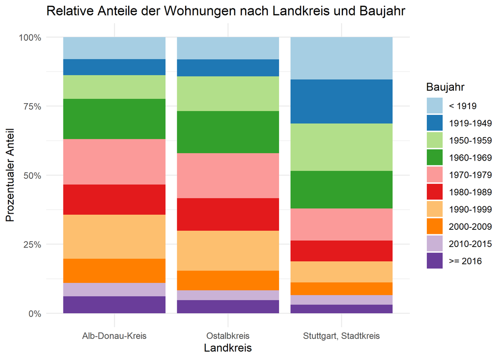

Ein Grund für den größeren relativen Anteil älterer Wohnungen könnte der begrenzte Platz innerhalb der Städte sein. In der Stadt gibt es nur eine feste Anzahl an Grundstücken, die bebaut werden können, und die Fläche selbst ist im Vergleich zum Land sehr klein. Auf dem Land hingegen stehen viele Baugrundstücke zur Verfügung, zudem sind die Baukosten deutlich günstiger, was den Bau von Häusern auf dem Land attraktiver macht. Hinzu kommen die extrem hohen Grundstückskosten in der Stadt, die teilweise für Spekulationen genutzt werden, anstatt zum Bau von Wohnungen. Dies führt dazu, dass die bebaubare Fläche innerhalb der Städte weiter sinkt.

Politische Maßnahmen, die in die Eigentumsrechte eingreifen, sehe ich kritisch, da niemand verpflichtet werden kann, ein Haus zu bauen. Zudem ist die Enteignung von Grundstücken oder Häusern eine komplexe Maßnahme. Dennoch sollte der Staat mehr Schritte unternehmen, um stark betroffene Gruppen zu unterstützen, möglicherweise durch den sozialen Wohnungsbau. Eine weitere mögliche Maßnahme wäre, Bürger direkt in den Wohnungsbau zu integrieren, indem sie Eigentümer der Wohnungen werden. Besonders interessiert mich das Konzept aus Singapur, bekannt als “Eigenheim für alle” (siehe [Link zur Tagesschau](https://www.tagesschau.de/wirtschaft/weltwirtschaft/immobilienmarkt-singapur-101.html)). Hier wird sozial schwächeren Familien ein durch den Staat subventionierter Mietkauf angeboten. Dank der Subventionierung haben diese Familien die Möglichkeit, Eigentum zu einem mietähnlichen Betrag zu erwerben. Dadurch wird der Staat entlastet, da weniger Sozialwohnungen finanziert werden müssen. Dieser Ansatz ist zudem nachhaltiger, da die Kinder dieser Familien später keine Miete mehr zahlen müssen. Dies fördert die Unabhängigkeit von sozialen Leistungen, zudem können durch den Verkauf Gewinne erzielt werden, wodurch auch der Lock-in-Effekt verhindert werden kann. Dieses Konzept könnte den sozialen Ungleichgewichten auf dem Wohnungsmarkt entgegenwirken und dazu beitragen, dass Familien langfristig planen können, während gleichzeitig der Bedarf an bezahlbaren Wohnungen gedeckt wird.

In einem weiteren Schritt sollen Sie nun die Mietpreise und deren Verteilung analysieren. Hierbei sollen Sie neben der Leerstands- und Eigentümerquote auch auf die Verteilung der Wohnungen nach deren Wohnfläche achten und diese untersuchen.

17 (a). Erstellen Sie zuerst eine Tabelle, die die durchschnittlichen Mietpreise mit der Leerstands- und Eigentümerquote darstellt. Was fällt ihnen dabei besonders auf? Beschreiben und interpretieren Sie ihre Tabelle.

17 (b). Erstellen Sie eine weitere Grafik, die die Verteilung der Wohnungen nach den einzelnen Wohnungsgrößen(<40m² bis >=200m²) abbildet. Stellen Sie darüber hinaus den durchschnittlichen Mietpreis je Landkreis in einer weiteren Grafik dar. Beschreiben und interpretieren Sie ihre Grafiken. Gehen Sie insbesondere auf die Frage ein, ob es Sinn macht sich vor allem den Ostalbkreis oder Alb-Donau-Kreis als ein Ganzes anzusehen und inwieweit überhaupt ein Vergleich zwischen Stadt und ländlicher Region möglich ist.

*Hinweis:* Hier sollen Sie erneut auf dieselben Städte und Landkreise aus Aufgabe 16 eingehen!

| Vergleich Ausgewählter Städte Gemeinde | Vergleich Ausgewählter Städte Durchschn. Mietpreis (€ pro m²) | Vergleich Ausgewählter Städte Leerstandsquote (%) | Vergleich Ausgewählter Städte Eigentümerquote (%) |
| --- | --- | --- | --- |
| Alb-Donau-Kreis | 6.37 | 5.34 | 71.44 |
| Ostalbkreis | 6.27 | 5.09 | 70.59 |
| Stuttgart, Stadtkreis | 10.39 | 3.46 | 31.15 |

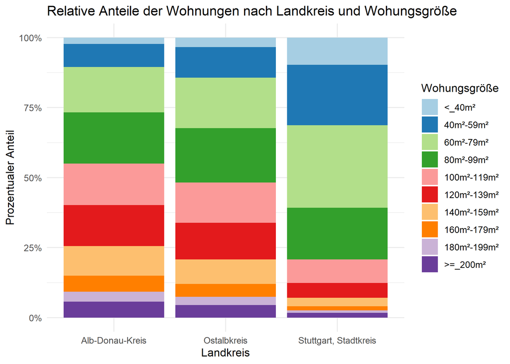

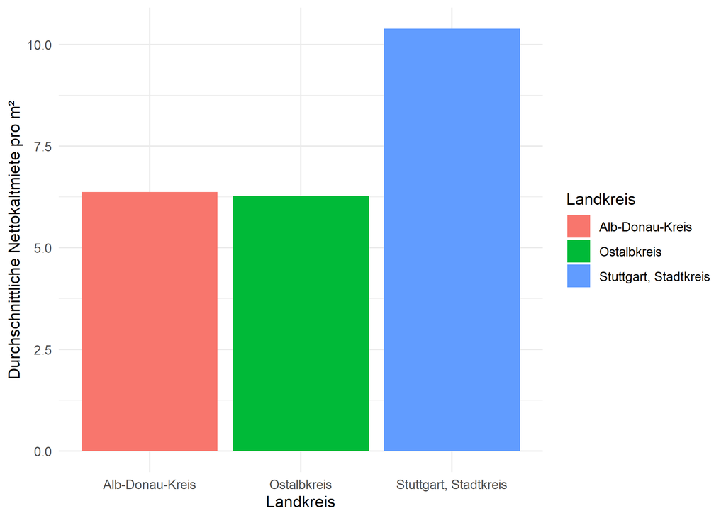

1. In der Tabelle zeigt sich, dass die durchschnittlichen Mietpreise in den beiden Landkreisen bei etwa 6,3 € pro Quadratmeter liegen, während der Quadratmeterpreis in der Stadt bei 10,3 € pro Quadratmeter liegt. Zudem fällt ein Unterschied bei der Leerstandsquote von etwa 2 Prozentpunkten auf.

Bemerkenswert ist, dass die beiden ländlichen Kreise eine Eigentümerquote aufweisen, die um etwa 40 Prozentpunkte höher liegt als in der Stadt Stuttgart. Dies stellt einen erheblichen Unterschied zur städtischen Situation dar. In Verbindung mit den niedrigeren Mietpreisen lässt sich daraus schließen, dass die in der vorherigen Analyse erwähnten Bau- und Grundstückskosten einen erheblichen Einfluss auf den Anteil der Eigentumswohnungen haben. Zudem zeigt sich, dass günstigere Baukosten auch die Mietpreise beeinflussen, die dadurch etwa 40 % niedriger als in der Stadt ausfallen. Die zwei Prozentpunkte Unterschied in der Leerstandsquote könnten möglicherweise auf die weniger attraktive ländliche Lage zurückzuführen sein. Manche Ortschaften sind weiter von wichtigen Infrastrukturen wie Einkaufsläden oder Krankenhäusern entfernt, was dazu führen kann, dass sich weniger Menschen finden, die bereit sind, dort zu wohnen. Darüber hinaus könnte die Leerstandsquote Einfluss auf die Mietpreise haben, da das größere Angebot an freien Wohnungen den Mietern mehr Auswahlmöglichkeiten gibt. In der Stadt ist das Angebot dagegen begrenzter, was den Preis steigen lässt.

2. Die erste Grafik stellt die Verteilung der Wohnungsgrößen innerhalb der Landkreise und Stuttgart dar. Hier zeigt sich, dass die Landkreise kleinere Unterschiede im Vergleich zur Stadt aufweisen. Auch zeigt die Grafik, dass die Verteilung der Wohnungsgrößen auf dem Land ausgeglichener ist als in der Stadt.

Die zweite Grafik ist ein einfaches Balkendiagramm, welches die Unterschiede in den Mietpreisen hervorhebt.

Der Vergleich zwischen Stadt und Land kann sehr aufschlussreich sein, um zu verstehen, wie sich verschiedene Merkmale wie Mieten oder Wohnungsgrößen verhalten. Dennoch sollte man einige Faktoren im Kopf behalten. Es kann unterschiedliche Datengrundlagen zwischen der Stadt und dem Land geben, die die Analyse beeinflussen können. Beispielsweise können aufgrund der höheren Bevölkerungsdichte und besseren Infrastruktur innerhalb der Stadt verlässlichere Erhebungen durchgeführt werden, wodurch qualitativ hochwertigere Daten vorliegen. Des Weiteren können wirtschaftliche Faktoren die Daten beeinflussen. In einem Landkreis, der stark von Landwirtschaft geprägt ist, können größere Wohnungen vorhanden sein, da für landwirtschaftliche Betriebe mehr Platz benötigt wird. Auch demografische Unterschiede, die hier nicht berücksichtigt wurden, könnten einen Einfluss auf die Miete oder Wohnungsgröße haben. Deshalb sollten Unterschiede in den Strukturen zwischen Land und Stadt sorgfältig hervorgehoben werden, um fundierte Aussagen über die Daten treffen zu können. Landkreise könnten zudem aufgrund ihrer Bevölkerungsdichte zu einer verzerrten Analyse der Daten führen, da hier mit kumulierten Daten der einzelnen Kreise gearbeitet wird, die in ihrer Bevölkerung unterschiedliche Merkmale aufweisen.

# Zusatzfrage (optional)

Diese Frage ist von der Bearbeitung her etwas schwieriger. Bevor Sie sich an diese Aufgabe machen, sollten Sie sicherstellen, dass Sie alle vorherigen Fragen ausführlich beantwortet haben. Eine korrekte Beantwortung dieser Frage gibt einen Punktebonus von 3 Punkten (das Projekt umfasst insgesamt 30 Punkte, inkl. Screencast).

Nachdem Sie sich in den bisherigen Aufgaben ausführlich mit den allgemeinen Einflussfaktoren auf die Mietpreise befasst haben, rückt nun ein spezifischer Aspekt in den Fokus: die Rolle der Heizungen. Insbesondere werden Sie untersuchen, wie unterschiedliche Heizungsarten und -systeme die Mietpreise beeinflussen können. Diese Betrachtung ermöglicht es ihnen, die bisherigen Analysen zu verfeinern und den Zusammenhang zwischen energetischen Standards und der Entwicklung von Mietkosten genauer zu erfassen. Aufgabe 18 führt Sie somit zu einem weiteren zentralen Detail der Mietpreisentwicklung, das insbesondere vor dem Hintergrund steigender Energiepreise und der Relevanz nachhaltiger Wohnformen an Bedeutung gewinnt.

18. Lesen Sie den Datensatz `Heiztypen_Zensus.csv` ein und speichern diesen als `heiztypen` ab. Neben den Ihnen bekannten Variablen, finden Sie dort 6 weitere Variablen, die Auskunft über die Heizarten der jeweiligen Wohnung geben. Diese werden wie folgt beschrieben:
- HEIZTYP__1: Gebäude mit Heizungsart Fernheizung (Fernwärme) (Anzahl)
- HEIZTYP__2: Gebäude mit Heizungsart Etagenheizung (Anzahl)
- HEIZTYP__3: Gebäude mit Heizungsart Blockheizung (Anzahl)
- HEIZTYP__4: Gebäude mit Heizungsart Zentralheizung (Anzahl)
- HEIZTYP__5: Gebäude mit Heizungsart Einzel- oder Mehrraumöfen (auch Nachtspeicherheizung) (Anzahl)
- HEIZTYP__6: Gebäude mit Heizungsart Keine Heizung im Gebäude oder in den Wohnungen (Anzahl)

Erstellen Sie eine neue Spalte `heiztypen_gesamt`, welche die Summe über alle Heiztypen hinweg bildet. Bestimmen Sie weiterhin den Anteil der jeweiligen Heiztypen je Gemeinde (als Anteil aller Heizarten). Nun sollen Sie eine oder mehrere passende Grafik(en) erzeugen, die je nach durchschnittlicher Größe der Wohnungen die Anteile der verschiedenen Heizungsarten abbilden. Erstellen Sie weiterhin eine oder mehrere passende Grafik(en) die den Zusammenhang zwischen den Heizungsarten und den durschnittlichen Mietpreisen darstellt. Wiederum soll der Anteil der verschiedenen Heizungsarten abhängig der Mietpreise abgebildet werden.

Beschreiben und interpretieren Sie ihre Schaubilder und gehen Sie insbesondere auf folgende Frage ein:

- Gibt es einen Zusammenhang zwischen der Heizungsart und der Größe der Wohnungen?
- Gibt es einen Zusammenhang zwischen der Heizungsart und den Mietpreisen?
- Was könnten Gründe sein, warum in bestimmten Wohnungsgrößen eher bestimmte Heizungstypen eingebaut werden und andere nicht?
- Warum könnte es sein, dass bei manchen Heizungsarten die Mietpreise höher sind als bei anderen?
- Was könnte die Bundesregierung machen, um trotz neuer und moderner Heizungssysteme die Mietpreise nach oben hin zu beschränken?

*Hinweis 1:* Überlegen Sie sich, ob es ihrer Ansicht nach Sinn macht, die jeweiligen Wohnungsgrößen und durchschnittlichen Mietpreise in Segmente zu unterteilen.

*Hinweis 2:* Eine Möglichkeit die Beziehung zwischen Heizungsarten und Wohnungsgrößen bzw. Heizungsarten und Mietpreisen zu visualisieren wäre beispielsweise ein “stacked” oder “grouped” Balkendiagramm. Überlegen Sie sich, warum diese Form der Darstellung besonders gut geeignet wäre.

[figure not shown]

–Zusammenhang zwischen Heizungsart und Wohnungsgröße:

-Fernheizung: Wird häufig in größeren Wohnungsgebäuden verwendet, insbesondere in urbanen Gebieten, wo Fernwärme verfügbar ist.

-Etagenheizung: Kommt häufiger in kleineren bis mittelgroßen Wohnungen vor.

-Blockheizungen und Zentralheizungen: Diese Systeme sind effizienter für mittlere bis große Wohneinheiten.

-Einzelöfen und keine Heizung: Diese Heizarten finden sich eher in kleineren oder älteren Wohnungen.

–Zusammenhang zwischen Heizungsart und Mietpreisen:

-Wohnungen mit Fernheizung und Zentralheizung neigen dazu, höhere Mietpreise zu haben, da diese Heizsysteme komfortabler und energieeffizienter sind. -Einzelöfen oder Wohnungen ohne Heizung sind in der Regel günstiger, da sie weniger komfortabel sind und höhere Energiekosten für die Mieter bedeuten.

–Gründe für bestimmte Heizungstypen bei verschiedenen Wohnungsgrößen:

Größere Wohngebäude setzen meist auf Blockheizkraftwerke oder Fernwärme, da diese sehr effizienter sind, wenn viele Wohnungen beheitzt werden müssen. Kleinere Wohnungen hingegen nutzen oft Einzelöfen oder Etagenheizungen, da sie für kleine Wohnungen ausreichend und günstiger in der Anschaffung sind.

–Gründe für höhere Mietpreise bei bestimmten Heizungstypen:

Moderne und zentralisierte Heizsysteme sind effizienter und erhöhen gleichzeitig den Komfort für die Mieter, was mit höheren Mietpreisen verbunden sein kann. Ältere Heizsysteme wie z.B. Einzelöfen sind ineffizient und machen Wohnungen weniger attraktiv, was zu geringeren Mietpreisen führen kann.

–Maßnahmen unserer Bundesregierung:

Die Bundesregierung könnte Maßnahmen wie Mietpreisobergrenzen nach Sanierungen einführen, um sicherzustellen, dass energetische Modernisierungen nicht zu übermäßigen Mieterhöhungen führen. Zusätzlich könnten Subventionen oder Steueranreize für energieeffiziente Heizsysteme eingeführt werden, um Vermieter zu ermutigen, modernere Heizsysteme ohne drastische Mietpreiserhöhungen zu installieren.

Wie Sie in der Aufgabe 15 gesehen haben, haben Ulm und Stuttgart, sowie Dresden und Chemnitz ähnliche Verhältnisse bezüglich der Verteilung der Mietkosten über die Stadt hinweg. Aufgrund dessen beschränken Sie sich bei dieser Aufgabe auf die Städte Stuttgart und Dresden. Hier sollen Sie sich die einzelnen Heizungsarten über die Stadtteile hinweg anschauen, wie sich diese verteilen und ob hier Ähnlichkeiten zur Mietpreissstrukur vorliegt. Weiterhin sind vor allem die Heizungsarten Fernwärme, Zentralheizung und Etagenheizung in viele deutschen Wohnungen größtenteils verbaut, weshalb Sie gerade deswegen diese drei Heiztypen genauer beleuchten und untersuchen sollen.

19. Deshalb sollten Sie sich in einem ersten Schritt [diese Geogitter-Daten für die verschiedenen Heinzungsarten vom statistischen Bundesamt herunterladen](https://www.zensus2022.de/static/Zensus_Veroeffentlichung/Zensus2022_Heizungsart.zip). Speichern Sie die zip-Datei im Ordner `Daten` ab. Nutzen Sie erneut den Datensatz shape_file aus der Aufgabe 4 und joinen Sie die Informationen zu den Heizungsarten über die Variablen `x_mp_1km` und `y_mp_1km`.

In ihrem Datensatz können Sie sehen, dass es Einträge mit “-” gibt. Diese sollen sie für alle Heizungstypen durch 0 ersetzen. Achten Sie auch darauf, dass über alle Heizungstypen hinweg die Werte als numeric vorliegen.

Erstellen Sie nun für die Heizungsarten “Fernheizung”, “Etagenheizung” und “Zentralheizung” eine neue Spalte mit dem Anteil des jeweiligen Heizungstyps an allen Heizungen (`Insgesamt_Heizungsart`) je Gemeinde. Schließlich sollen Sie nun für die drei genannten Heizungsarten eine Karte erzeugen, welche den Anteil je Gitterebene im Stadtbezirk darstellt.

Beschreiben und interpretieren Sie ihre Grafiken. Berücksichtigen Sie dabei insbesondere folgende Fragen:

- Wo liegen Besonderheiten oder Muster in beiden Städten?
- Gibt es in Stuttgart und Dresden Stadtteile, bei denen bestimmte Heizungstypen in Einklang mit den Mietpreisen stehen, genauer gesagt, welche Heizungsarten korrelieren mit höheren oder niedrigeren Mietpreisen? Vergleichen Sie dazu die Ergebnisse aus Aufgabe 15.
- Was könnten Gründe sein, dass in bestimmten Stadtteilen vorwiegend eine bestimmte Form der Heizung eingebaut ist?
- Gibt es Unterschiede zwischen Ost- und Westdeutschland?
- Haben die Städte Stuttgart oder Dresden in den letzen Jahren Modernisierungen angestoßen oder Neuerungen umgesetzt und finanziell unterstützt, sodass es dort zu größeren Anpassungen bei der Heizungstechnik kam?

*Hinweis 1:* Sie sollen insgesamt für jede Stadt (Stuttgart und Dresden) drei verschiedene Karten erzeugen.

*Hinweis 2:* Achten Sie auf eine sinnvolle Einteilung und Darstellung in den Karten. Nutzen Sie die Karten aus vorherigen Aufgaben als Hilfestellung.

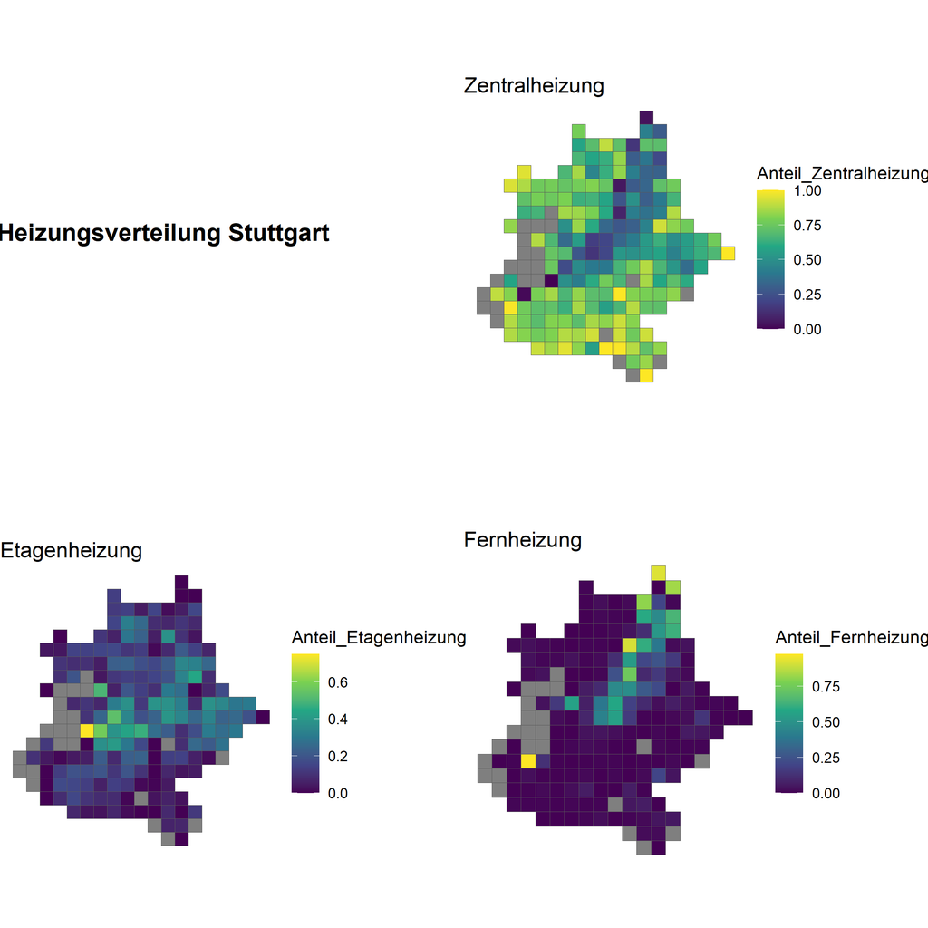

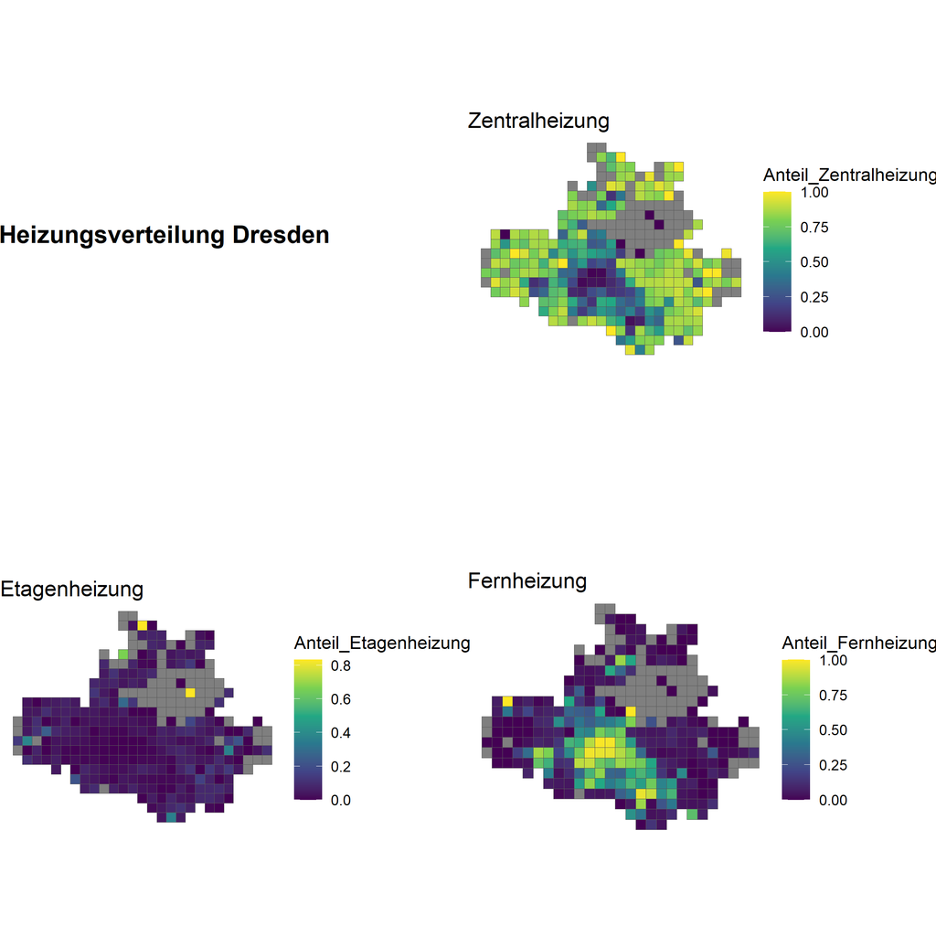

Die beiden Grafiken zeigen die Verteilung von drei Heizungsarten in den Städten Dresden und Stuttgart. Die Farbskala verläuft von dunkelblau (geringer Anteil) bis gelb (hoher Anteil).

In Dresden erkennt man, dass die Fernheizung die am stärksten vertretene Heizungsform im Zentrum der Stadt ist. Dies deutet auf moderne Gebäude hin, da diese Art der Heizung häufig in neueren oder renovierten Gebäuden verwendet wird. Die Etagenheizungen hingegen sind in Dresden kaum vertreten und eher im Randgebiet sichtbar, was vermutlich auf ältere und weniger moderne Gebäude hindeutet. Die Heizungsart Zentralheizung ist in Dresden sehr stark in den Randgebieten vertreten.

In Stuttgart zeigt sich ein anderes Bild: Hier ist vor allem die Zentralheizung sehr gleichmäßig über das Stadtgebiet verteilt, sowohl in zentralen als auch in den Randgebieten, was auf eine breite Nutzung dieser Heizungsart hindeutet. Dennoch gibt es Stadtteile mit geringen Anteilen. Die Fernheizung ist in Stuttgart deutlich weniger verbreitet. Es gibt ein paar Stadtteile mit höheren Anteilen im Nordosten der Stadt, doch in den meisten Stadtteilen ist diese Heizungsform kaum bis gar nicht vertreten. Die Etagenheizung ist in Stuttgart stärker als in Dresden vertreten; es finden sich moderate bis hohe Anteile besonders in einigen zentralen Gebieten. Im Süden der Stadt ist die Etagenheizung hingegen kaum vertreten.

Aus Aufgabe 15 zeigt sich, dass Heizungsarten und Mietpreise eine Korrelation aufweisen. In Dresden zeigen die Grafiken einen Zusammenhang zwischen Fernheizungen und hohen Mietpreisen: Beide treten in zentraler Lage auf. Dies könnte darauf hindeuten, dass Fernheizungen vor allem in teuren, zentral gelegenen Wohnungen genutzt werden. Im Randgebiet von Dresden sind niedrigere Mietpreise zusammen mit Zentralheizungen vertreten, was auf einen Zusammenhang zwischen günstigeren Wohnungen und Zentralheizungen hinweisen könnte. Da Etagenheizungen in Dresden kaum vertreten sind, lässt sich hier keine korrekte Aussage treffen.

Die Verteilung bestimmter Heizungsarten kann auf mehrere Ursachen zurückgeführt werden: Zum einen war die Fernwärme in der DDR ein häufig genutztes Konzept, da hier zentralisiert und effizient Häuser beheizt werden konnten. Nach der Wiedervereinigung wurden diese Strukturen beibehalten und weiterverwendet. Deshalb verfügt Dresden – wie auch andere ostdeutsche Städte – heute über ein gut ausgebautes Fernwärmenetz. In Stuttgart dagegen wurde historisch auf die individuelle Versorgung durch Brennstoffe gesetzt, was sich bis heute in den Heizungssystemen zeigt. Zentralheizungen kommen dennoch in beiden Städten häufig vor; besonders in modernisierten oder Neubauten werden sie installiert. Durch die hohen Modernisierungskosten steigen auch die Mieten – diese Gebäude befinden sich häufig am Stadtrand, da Städte durch Bevölkerungszuwachs nach außen wachsen. Etagenheizungen sind vor allem in älteren Gebäuden oder nicht modernisierten Häusern anzutreffen, da sie eine schnelle und kostengünstige Maßnahme zur Beheizung darstellen und bei Ausfall leicht ersetzt werden können. Vor allem kleinere Häuser mit weniger Wohneinheiten sind wirtschaftlicher mit Etagenheizungen auszustatten.

Im Osten wird eher auf Fernwärme als Heizungsform gesetzt; in Stuttgart wird historisch Erdgas als Energieträger bevorzugt. Dresden hat Förderprogramme für energieeffiziente Heizungssysteme aufgelegt, darunter den Austausch alter Heizkessel gegen effiziente Systeme wie Wärmepumpen. Stuttgart bietet ebenfalls Förderprogramme für energetische Sanierungen an, darunter für den Austausch von Ölheizungen; besonders gefördert werden Maßnahmen für Wärmepumpen. Zudem plant Stuttgart zukünftig die Umstellung des Methan-Gasnetzes auf ein Wasserstoffnetz, wodurch bestehende Strukturen weiter genutzt werden können – mit einem umweltfreundlicheren Brennstoff.

Abschließend sollen Sie die Zusatzaufgabe noch einmal rekapitulieren und einige Fragen dazu beantworten.

20. Sie sollen sich noch einmal bewusst werden, was Sie in den vorherigen Aufgaben analysiert haben und in welcher Form ihre Ergebnisse anwendbar und verallgemeinbar sind. Beantworten Sie dazu Frage 1 und 2.

Frage 1: Betrachten Sie hierzu noch einmal exemplarisch die Städte Stuttgart und Dresden.

- Sind die Zusammenhänge zwischen Mietpreisen in den Städten und sozioökonomischer Faktoren vor allem auf Unterschiede zwischen den Städten oder auf Unterschiede innerhalb der Stadt zurückzuführen. Bei welchen Faktoren ist dies der Fall, wo nicht?
- Wie kann der Staat im Hinblick auf die unterschiedlichen Heizungsarten in den Städten eingreifen, um Wohnraum preiswerter zu gestalten?

Frage 2: Schauen Sie sich noch einmal die Verteilung der Heizungsarten (Fern-, Etagen- und Zentralheizungen) für Stuttgart und Dresden in Aufgabe 19 an. Betrachten Sie im Vergleich dazu ihre Grafik aus Aufgabe 8, sowie ihre Tabelle in Aufgabe 13?

- Was fällt Ihnen hier auf?
- Gibt es bestimmte Heizungstypen, die nur in alten oder neuen Wohnungen vorkommen?
- Welche Schlüsse würden Sie ziehen, die mit Handlungen der Politik einhergehen?
1. Zusammenhang zwischen Mietpreisen und sozioökonomischen Faktoren:

Unterschiede zwischen den Städten: Die Mietpreise hängen in hohem Maße vom wirtschaftlichen Kontext einer Stadt ab. Besonders Städte mit einer starken Industrie- und Wirtschaftsstruktur sind in der Regel attraktiver für Arbeitskräfte. Stuttgart ist ein bedeutender Industriestandort, insbesondere im Automobilsektor, was es zu einem bevorzugten Ziel für Arbeitskräfte macht. Im Gegensatz dazu hat Dresden eine schwächere Wirtschaftsstruktur, was sich auch auf die Mietpreise auswirkt. Menschen streben nach Wohlstand und entscheiden sich daher eher für Städte mit besseren Arbeitsmöglichkeiten. Diese höhere Nachfrage führt zu einem Anstieg der Mietpreise.

Ein weiterer wichtiger Faktor, den wir im Projekt untersucht haben, ist die Migration. Migranten neigen dazu, sich in wirtschaftlich starken Regionen anzusiedeln. Da Stuttgart ein wirtschaftlich stärkerer Standort ist, tendieren Migranten dazu, sich dort niederzulassen. Zudem spielt die Geburtenrate eine Rolle: Migranten haben oft größere Familien, was zu einem höheren Bevölkerungswachstum führt.

Ein weiterer Aspekt, der mit einer starken Wirtschaft verbunden ist, ist die verbesserte Infrastruktur und Lebensqualität. Wenn eine Stadt über eine gut ausgebaute Infrastruktur verfügt, wirkt sich das auch auf die Mietpreise aus. Stuttgart bietet eine bessere Infrastruktur als Dresden, was sich in höheren Mietpreisen niederschlägt.

Unterschiede innerhalb der Stadt: Ein weiterer Punkt, den wir im Projekt behandelt haben, ist die Bedeutung der verschiedenen Stadtteile. In jeder Stadt gibt es sowohl wohlhabende Wohngegenden als auch weniger bevorzugte Gebiete, die häufig als „Ghettos“ bezeichnet werden. Diese Unterschiede wirken sich direkt auf die Mietpreise aus. Weniger attraktive Gegenden, wie sogenannte „Slums“, sind für viele Menschen unattraktiv, was sich in niedrigeren Mietpreisen widerspiegelt. Im Gegensatz dazu ist die Zahlungsbereitschaft in beliebten, gut ausgestatteten Stadtteilen höher. Beispiele für sozial schwächere Gebiete sind in Stuttgart etwa Bad Cannstatt und in Dresden die östlichen Stadtteile.

2. Bei der Betrachtung der Mietkosten müssen auch die Heizkosten berücksichtigt werden, was bereits in den Bonusaufgaben thematisiert wurde. Eine Senkung der Heizkosten würde einen erheblichen Beitrag zur Reduzierung der Gesamtwohnkosten leisten. Eine Möglichkeit zur Kostensenkung wäre die Förderung von energieeffizienten Heizsystemen. Wenn der Staat private Haushalte dabei unterstützen würde, auf moderne, energieeffiziente Heiztechnologien umzurüsten und veraltete, ineffiziente Heizungen zu ersetzen, könnten die Einsparungen schon kurzfristig beträchtlich sein. Auch eine verstärkte Förderung erneuerbarer Energien könnte indirekt durch Steuererleichterungen (wie z. B. eine CO₂-Steuer) die Heizkosten senken und somit die Gesamtwohnkosten reduzieren.

Zusätzlich könnte der Staat durch gezielte Sanierungsprogramme die Energieeffizienz von Neubauten und Bestandsgebäuden verbessern. Besonders durch die Renovierung alter Gebäude und die Installation guter Isolierung ließen sich die Heizkosten erheblich senken. Zu guter Letzt könnte der Staat auch Preisregulierungen für Heizkosten einführen. Es gibt unterschiedliche Heizsysteme, deren Kosten stark variieren. Eine Regulierung der Preise für die teureren Heizsysteme würde helfen, die Kosten für die Mieter zu senken.

2. In Dresden zeigt sich, dass die teuren Mietwohnungen in der Innenstadt hauptsächlich mit Fernwärme beheizt werden, während in den äußeren Stadtteilen eher Zentralheizungen zum Einsatz kommen. Etagenheizungen werden in Dresden nur selten verwendet.

In Stuttgart ist es umgekehrt: Die Gebiete mit Fernwärme befinden sich hauptsächlich in den äußeren Stadtteilen, während in den teureren innerstädtischen Gegenden eher Etagenheizungen zu finden sind. In den äußeren Stadtgebieten von Stuttgart wird vermehrt auf Zentralheizung gesetzt.

Es lässt sich also feststellen, dass der Staat versucht, die hohen Heizkosten zu verringern, insbesondere durch den Umstieg auf effizientere Heizsysteme. Fernwärme hat den Nachteil, dass dabei viel Energie verloren geht und die Kosten hoch sind. Daher liegt der Fokus bei Neubauten und in der Stadtplanung zunehmend auf Zentralheizungen.